# Materi-1

# Library/Packages

```r
library(forecast)
```

```r
library(graphics)
library(TTR)
library(TSA)
library(rio)
library(ggplot2)
```

# Import Data

Data yang digunakan adalah **Data PJME**, yaitu data konsumsi listrik yang dicatat secara **per jam (hourly)**. Data ini terdiri dari dua variabel utama, yaitu **Datetime** yang menunjukkan waktu pengamatan dan **PJME_MW** yang menunjukkan jumlah konsumsi listrik dalam satuan megawatt (MW).

```r
# Import data
data1 <- import("Data_Tugas2.csv")

# Lihat struktur data
head(data1)
```

```
##              Datetime PJME_MW
## 1 2002-12-31 01:00:00   26498
## 2 2002-12-31 02:00:00   25147
## 3 2002-12-31 03:00:00   24574
## 4 2002-12-31 04:00:00   24393
## 5 2002-12-31 05:00:00   24860
## 6 2002-12-31 06:00:00   26222
```

```r
str(data1)
```

```
## 'data.frame':    145366 obs. of  2 variables:
##  $ Datetime: POSIXct, format: "2002-12-31 01:00:00" "2002-12-31 02:00:00" ...
##  $ PJME_MW : num  26498 25147 24574 24393 24860 ...
```

## 1. Ambil 50.000 Observasi Terbaru

```r
# Ubah Datetime menjadi format tanggal dan waktu
data1$Datetime <- as.POSIXct(
  data1$Datetime,
  format = "%Y-%m-%d %H:%M:%S"
)

# Urutkan data1 berdasarkan waktu
data1 <- data1[order(data1$Datetime), ]

# Ambil 50.000 observasi paling baru
data2 <- tail(data1, 50000)

# Pastikan kembali urut secara kronologis
data2 <- data2[order(data2$Datetime), ]

# Cek ukuran data
dim(data2)
```

```
## [1] 50000     2
```

```r
# Cek awal dan akhir data
head(data2)
```

```
##                  Datetime PJME_MW
## 88673 2012-11-18 14:00:00   27648
## 88674 2012-11-18 15:00:00   27498
## 88675 2012-11-18 16:00:00   27769
## 88676 2012-11-18 17:00:00   29458
## 88677 2012-11-18 18:00:00   32330
## 88678 2012-11-18 19:00:00   32597
```

```r
tail(data2)
```

```
##                   Datetime PJME_MW
## 140250 2018-08-02 19:00:00   45641
## 140251 2018-08-02 20:00:00   44057
## 140252 2018-08-02 21:00:00   43256
## 140253 2018-08-02 22:00:00   41552
## 140254 2018-08-02 23:00:00   38500
## 140255 2018-08-03 00:00:00   35486
```

Data yang digunakan terdiri atas 50.000 observasi terbaru dengan dua variabel, yaitu `Datetime` dan `PJME_MW`. Data telah diurutkan berdasarkan waktu sehingga urutan observasi sesuai dengan kronologi pengamatan. Periode data yang diperoleh dimulai pada 18 November 2012 pukul 14.00 hingga 3 Agustus 2018 pukul 00.00.

## 2. Ambil 10.000 Observasi

```r
data3 <- data2[1:10000, ]

# Cek data
dim(data3)
```

```
## [1] 10000     2
```

```r
head(data3)
```

```
##                  Datetime PJME_MW
## 88673 2012-11-18 14:00:00   27648
## 88674 2012-11-18 15:00:00   27498
## 88675 2012-11-18 16:00:00   27769
## 88676 2012-11-18 17:00:00   29458
## 88677 2012-11-18 18:00:00   32330
## 88678 2012-11-18 19:00:00   32597
```

```r
tail(data3)
```

```
##                   Datetime PJME_MW
## 113713 2014-01-09 02:00:00   33945
## 113714 2014-01-09 03:00:00   33295
## 113715 2014-01-09 04:00:00   33330
## 113716 2014-01-09 05:00:00   34063
## 113717 2014-01-09 06:00:00   36116
## 113718 2014-01-09 07:00:00   39847
```

Dari 50.000 observasi tersebut, diambil 10.000 observasi pertama untuk digunakan dalam analisis. Data terdiri atas 10.000 observasi dengan variabel `Datetime` dan `PJME_MW`, dengan periode pengamatan mulai 18 November 2012 pukul 14.00 hingga 9 Januari 2014 pukul 07.00.

# Eksplorasi Data

`View()` : menampilkan data dalam bentuk tabel, `str()` : menampilkan struktur data, `dim()` : menampilkan dimensi data

```r
View(data3)
str(data3)
```

```
## 'data.frame':    10000 obs. of  2 variables:
##  $ Datetime: POSIXct, format: "2012-11-18 14:00:00" "2012-11-18 15:00:00" ...
##  $ PJME_MW : num  27648 27498 27769 29458 32330 ...
```

```r
dim(data3)
```

```
## [1] 10000     2
```

Mengubah data agar terbaca sebagai data deret waktu dengan fungsi `ts()`

```r
data3.ts <- ts(data3$PJME_MW)
```

Menampilkan ringkasan data

```r
summary(data3.ts)
```

```
##    Min. 1st Qu.  Median    Mean 3rd Qu.    Max.
##   19622   27627   31152   31759   35253   59122
```

## 1. Plot Deret Waktu untuk Seluruh Data

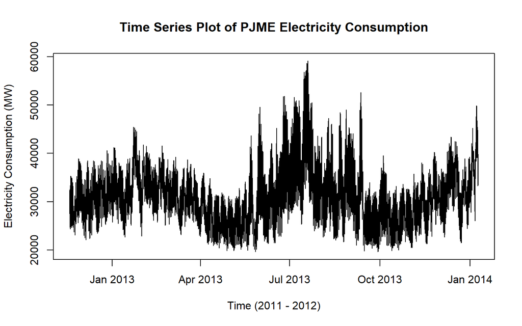

```r
plot(
  data3$Datetime, data3$PJME_MW,
  type = "l",
  xlab = "Time (2011 - 2012)",
  ylab = "Electricity Consumption (MW)",
  main = "Time Series Plot of PJME Electricity Consumption"
)
```

```r
# 6. Menyimpan plot
dev.copy(png, "plot_data3_bulan.png")
```

```r
dev.off()
```

Berdasarkan plot deret waktu seluruh data PJME, terlihat bahwa konsumsi listrik mengalami fluktuasi dari waktu ke waktu. Selain perubahan tingkat konsumsi, terdapat pola naik-turun yang berulang pada periode tertentu. Hal ini mengindikasikan adanya pola musiman dalam data konsumsi listrik.

## 2. Plot Deret Waktu untuk 14 Hari

Digunakan untuk melihat pola data.

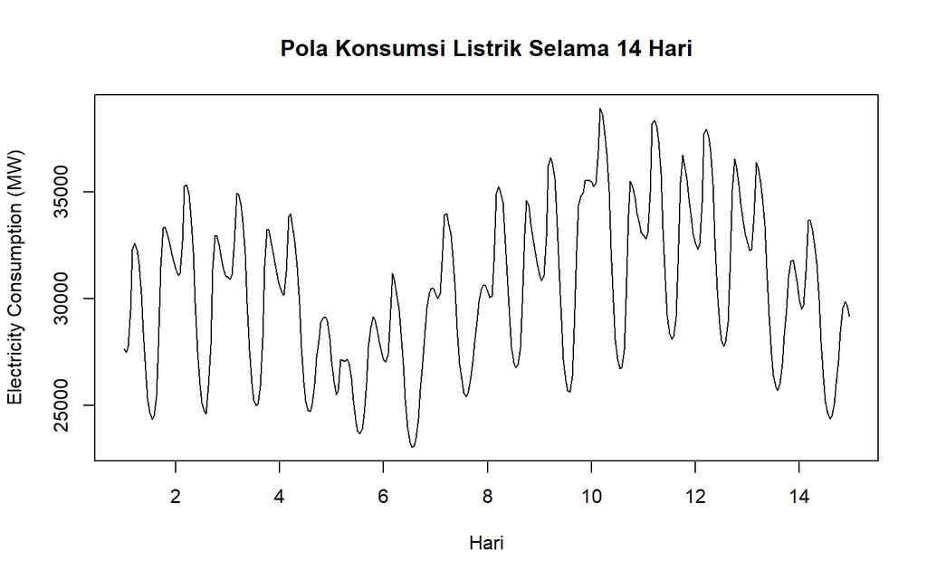

```r
# Ambil 14 hari pertama
data_14hari <- data3[1:336, ]

ts_14hari <- ts(
  data_14hari$PJME_MW,
  frequency = 24
)

ts.plot(
  ts_14hari,
  xlab = "Hari",
  ylab = "Electricity Consumption (MW)",
  main = "Pola Konsumsi Listrik Selama 14 Hari"
)
```

Berdasarkan plot konsumsi listrik selama 14 hari, terlihat adanya pola naik-turun yang berulang pada periode harian. Pola tersebut menunjukkan adanya indikasi **musiman harian**. Karena data dicatat setiap jam, dalam satu hari terdapat 24 observasi sehingga periode musiman yang digunakan adalah **m = 24**.

# Moving Average

## 1. Pembagian Data

Pembagian data latih dan data uji dilakukan dengan perbandingan 80% data latih dan 20% data uji.

```r
# Hitung jumlah data
n <- nrow(data3)

# tentukan batas 80%
n_train <- floor(0.8 * n)

# Bagi data training dan testing
training_ma <- data3[1:n_train, ]
testing_ma <- data3[(n_train + 1):n, ]

# Ubah ke time series
train_ma.ts <- ts(training_ma$PJME_MW)
test_ma.ts <- ts(testing_ma$PJME_MW)

# Cek
length(train_ma.ts)
```

```
## [1] 8000
```

```r
length(test_ma.ts)
```

```
## [1] 2000
```

## 2. Eksplorasi

Eksplorasi data dilakukan pada keseluruhan data, data latih serta data uji menggunakan plot data deret waktu.

```r
# Eksplorasi keseluruhan data
plot(data3.ts, col="red",main="Plot Semua Data")
```

[output not shown]

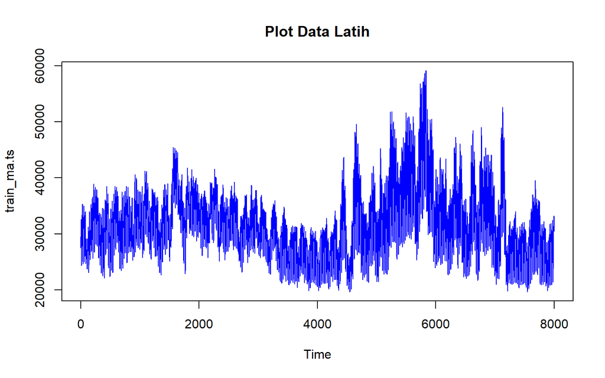

```r
# Eksplorasi data latih
plot(train_ma.ts, col="blue",main="Plot Data Latih")
```

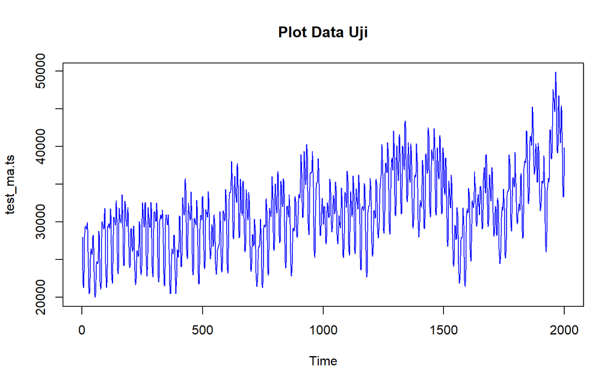

```r
# Eksplorasi data uji
plot(test_ma.ts, col="blue",main="Plot Data Uji")
```

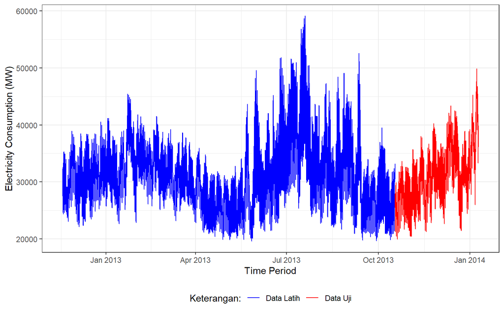

```r
ggplot() +
  geom_line(data = training_ma,
            aes(x = Datetime,
                y = PJME_MW,
                col = "Data Latih")) +

  geom_line(data = testing_ma,
            aes(x = Datetime,
                y = PJME_MW,
                col = "Data Uji")) +

  labs(x = "Time Period",
       y = "Electricity Consumption (MW)",
       color = "Legend") +

  scale_colour_manual(name="Keterangan:",
                      breaks = c("Data Latih", "Data Uji"),
                      values = c("blue", "red")) +

  theme_bw() + theme(legend.position = "bottom",
                     plot.caption = element_text(hjust=0.5, size=12))
```

## **3.** Single Moving Average (SMA)

Ide dasar dari Single Moving Average (SMA) adalah data suatu periode dipengaruhi oleh data periode sebelumnya. Metode pemulusan ini cocok digunakan untuk pola data stasioner atau konstan. Prinsip dasar metode pemulusan ini adalah data pemulusan pada periode ke-t merupakan rata rata dari m buah data pada periode ke-t hingga periode ke (t-m+1).

$$S_t = \frac{1}{m} \sum_{i=t-m+1}^{t} X_i$$
$$S_t = \frac{1}{m}
\sum_{i=t-m+1}^{t} X_i$$

Data pemulusan pada periode ke-t selanjutnya digunakan sebagai nilai peramalan pada periode ke t+1.

$$F_t = S_{t-1}, F_{n,h} =
S_n$$

Pemulusan menggunakan metode SMA dilakukan dengan fungsi `SMA()`. Dalam hal ini akan dilakukan pemulusan dengan parameter `m = 24`.

```r
data.sma<-SMA(train_ma.ts, n = 24)

head(data.sma, 100)
```

```
## Time Series:
## Start = 1
## End = 100
## Frequency = 1
##   [1]       NA       NA       NA       NA       NA       NA       NA       NA
##   [9]       NA       NA       NA       NA       NA       NA       NA       NA
##  [17]       NA       NA       NA       NA       NA       NA       NA 29432.38
##  [25] 29588.21 29739.00 29882.00 30016.75 30138.58 30252.46 30360.08 30452.38
##  [33] 30533.38 30589.88 30626.21 30652.71 30671.92 30687.58 30690.54 30710.62
##  [41] 30714.12 30710.71 30697.38 30680.17 30658.33 30627.58 30595.75 30569.21
##  [49] 30553.79 30545.62 30543.33 30541.38 30528.96 30510.17 30490.67 30479.33
##  [57] 30476.00 30475.50 30477.12 30481.00 30486.12 30497.25 30516.88 30516.08
##  [65] 30530.04 30534.08 30545.58 30556.71 30561.79 30565.29 30572.08 30567.33
##  [73] 30549.33 30522.54 30482.04 30424.46 30378.08 30340.50 30293.08 30255.71
##  [81] 30230.96 30228.54 30234.88 30237.33 30236.42 30226.62 30211.50 30177.00
##  [89] 30087.96 29908.67 29691.62 29510.79 29363.96 29244.25 29135.54 29019.33
##  [97] 28872.42 28700.21 28506.42 28274.83
```

Data pemulusan pada periode ke-t selanjutnya digunakan sebagai nilai peramalan pada periode ke t+1 sehingga hasil peramalan 1 periode kedepan adalah sebagai berikut.

```r
data.ramal <- c(NA, data.sma)
head(data.ramal, 100)
```

```
##   [1]       NA       NA       NA       NA       NA       NA       NA       NA
##   [9]       NA       NA       NA       NA       NA       NA       NA       NA
##  [17]       NA       NA       NA       NA       NA       NA       NA       NA
##  [25] 29432.38 29588.21 29739.00 29882.00 30016.75 30138.58 30252.46 30360.08
##  [33] 30452.38 30533.38 30589.88 30626.21 30652.71 30671.92 30687.58 30690.54
##  [41] 30710.62 30714.12 30710.71 30697.38 30680.17 30658.33 30627.58 30595.75
##  [49] 30569.21 30553.79 30545.62 30543.33 30541.38 30528.96 30510.17 30490.67
##  [57] 30479.33 30476.00 30475.50 30477.12 30481.00 30486.12 30497.25 30516.88
##  [65] 30516.08 30530.04 30534.08 30545.58 30556.71 30561.79 30565.29 30572.08
##  [73] 30567.33 30549.33 30522.54 30482.04 30424.46 30378.08 30340.50 30293.08
##  [81] 30255.71 30230.96 30228.54 30234.88 30237.33 30236.42 30226.62 30211.50
##  [89] 30177.00 30087.96 29908.67 29691.62 29510.79 29363.96 29244.25 29135.54
##  [97] 29019.33 28872.42 28700.21 28506.42
```

Selanjutnya dilakukan peramalan sebanyak 2000 periode sesuai dengan jumlah data uji. Pada metode SMA, seluruh hasil peramalan untuk 2000 periode ke depan akan memiliki nilai yang sama dengan hasil ramalan satu periode ke depan.

```r
data.gab <- cbind(
  aktual = c(data3.ts),
  pemulusan = c(data.sma,rep(NA, 2000)),
  ramalan = c(data.ramal,rep(data.ramal[length(data.ramal)], 1999)))

head(data.gab, 100)
```

```
##        aktual pemulusan  ramalan
##   [1,]  27648        NA       NA
##   [2,]  27498        NA       NA
##   [3,]  27769        NA       NA
##   [4,]  29458        NA       NA
##   [5,]  32330        NA       NA
##   [6,]  32597        NA       NA
##   [7,]  32270        NA       NA
##   [8,]  31642        NA       NA
##   [9,]  30224        NA       NA
##  [10,]  28451        NA       NA
##  [11,]  26656        NA       NA
##  [12,]  25330        NA       NA
##  [13,]  24678        NA       NA
##  [14,]  24365        NA       NA
```

[output cut: 86 more lines]

Adapun plot data deret waktu dari hasil peramalan yang dilakukan adalah sebagai berikut.

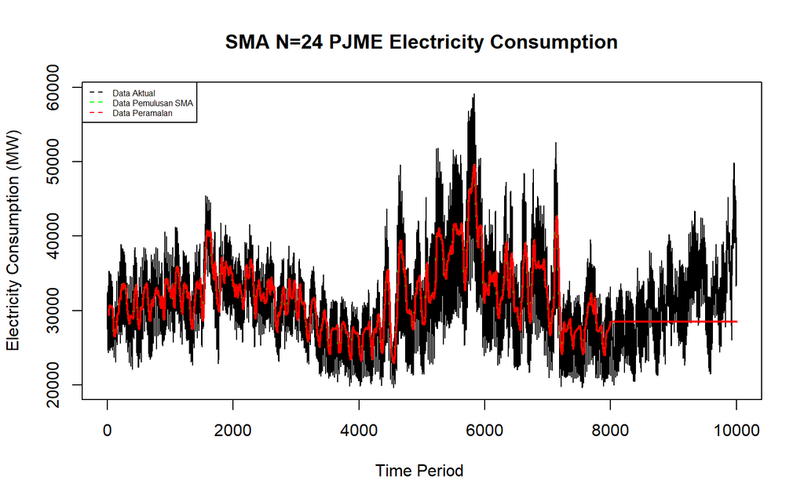

```r
ts.plot(
  data3.ts,
  xlab = "Time Period ",
  ylab = "Electricity Consumption (MW)",
  main = "SMA N=24 PJME Electricity Consumption"
  )

lines(data.gab[,2], col= "green",lwd=2)
lines(data.gab[,3], col= "red",lwd=2)

legend(
  "topleft",
  c("Data Aktual", "Data Pemulusan SMA", "Data Peramalan"),
  lty = 8,
  col = c("black","green","red"),
  cex = 0.5
  )
```

Selanjutnya perhitungan akurasi dilakukan dengan ukuran akurasi *Sum Squares Error* (SSE), *Mean Square Error* (MSE) dan *Mean Absolute Percentage Error* (MAPE). Perhitungan akurasi dilakukan baik pada data latih maupun pada data uji.

$$SSE = \sum_{t=1}^{n} (y_t -
\hat{y}_t)^2$$

$$MSE = \frac{1}{n} \sum_{t=1}^{n} (y_t -
\hat{y}_t)^2$$

$$MAPE = \frac{1}{n} \sum_{t=1}^{n}
\left|\frac{y_t - \hat{y}_t}{y_t}\right| * 100$$

### a. Akurasi Data Latih

```r
# Menghitung nilai keakuratan data latih
error_train.sma = train_ma.ts - data.ramal[1:length(train_ma.ts)]

SSE_train.sma = sum(
  error_train.sma[25:length(train_ma.ts)]^2
)

MSE_train.sma = mean(
  error_train.sma[25:length(train_ma.ts)]^2
)

MAPE_train.sma = mean(
  abs(
    (error_train.sma[25:length(train_ma.ts)] /
       train_ma.ts[25:length(train_ma.ts)]) * 100
  )
)

akurasi_train.sma <- matrix(
  c(SSE_train.sma, MSE_train.sma, MAPE_train.sma)
)

row.names(akurasi_train.sma) <- c("SSE", "MSE", "MAPE")
colnames(akurasi_train.sma) <- c("Akurasi m = 24")

akurasi_train.sma
```

```
##      Akurasi m = 24
## SSE    1.682042e+11
## MSE    2.108879e+07
## MAPE   1.212481e+01
```

Berdasarkan hasil perhitungan, metode SMA dengan m = 24 menghasilkan nilai MAPE sekitar **12.1%** pada data latih. Nilai tersebut menunjukkan bahwa rata-rata kesalahan absolut relatif hasil peramalan terhadap nilai aktual berada di sekitar 12.1%, sehingga performa peramalan pada data latih dapat dikategorikan **cukup baik**.

### b. Akurasi Data Uji

```r
# Menghitung nilai keakuratan data uji
error_test.sma = test_ma.ts - data.gab[8001:10000,3]

SSE_test.sma = sum(error_test.sma^2)

MSE_test.sma = mean(error_test.sma^2)

MAPE_test.sma = mean(
  abs((error_test.sma / test_ma.ts) * 100)
)

akurasi_test.sma <- matrix(
  c(SSE_test.sma, MSE_test.sma, MAPE_test.sma)
)

row.names(akurasi_test.sma) <- c("SSE", "MSE", "MAPE")

colnames(akurasi_test.sma) <- c("Akurasi m = 24")

akurasi_test.sma
```

```
##      Akurasi m = 24
## SSE    6.867529e+10
## MSE    3.433765e+07
## MAPE   1.416627e+01
```

Berdasarkan hasil perhitungan pada data uji, metode SMA dengan m = 24 menghasilkan nilai MAPE sebesar **14.2%**. Nilai tersebut menunjukkan bahwa rata-rata kesalahan absolut relatif hasil peramalan terhadap data aktual sekitar 14.2%, sehingga performa peramalan pada data uji dapat dikategorikan **cukup baik**.

## 4. **Double Moving Average (DMA)**

Metode pemulusan Double Moving Average (DMA) pada dasarnya mirip dengan SMA. Namun demikian, metode ini lebih cocok digunakan untuk pola data trend. Proses pemulusan dengan rata rata dalam metode ini dilakukan sebanyak 2 kali.

- **Tahap I:**

$$S_{1,t} = \frac{1}{m} \sum_{i=t-m+1}^{t}
X_i$$

- **Tahap II:**

$$S_{2,t} = \frac{1}{m} \sum_{i=t-m+1}^{t}
S_{1,i}$$

Forecast $h$ langkah ke depan dihitung dengan:

$$F_{2,t,t+h} = A_t + B_t
\,(h)$$

dengan komponen level ($A_t$) dan tren ($B_t$):

$$A_t = 2S_{1,t} - S_{2,t}
\qquad\text{dan}\qquad B_t = \frac{2}{m-1}\,\big(S_{1,t} -
S_{2,t}\big)$$

```r
dma <- SMA(data.sma, n = 24)
At <- 2 * data.sma - dma
Bt <- 2 / (24 - 1) * (data.sma - dma)
data.dma <- At + Bt
data.ramal2 <- c(NA, data.dma)


t <- 1:2000
f <- c()

for (i in t) {
  f[i] <- At[length(At)] + Bt[length(Bt)] * i
}

data.gab2 <- cbind(
  aktual = c(data3.ts),
  pemulusan1 = c(data.sma, rep(NA, 2000)),
  pemulusan2 = c(dma, rep(NA, 2000)),
  At = c(At, rep(NA, 2000)),
  Bt = c(Bt, rep(NA, 2000)),
  ramalan = c(data.ramal2, f[-1])
)

head(data.gab2, 100)
```

```
##        aktual pemulusan1 pemulusan2       At            Bt  ramalan
##   [1,]  27648         NA         NA       NA            NA       NA
##   [2,]  27498         NA         NA       NA            NA       NA
##   [3,]  27769         NA         NA       NA            NA       NA
##   [4,]  29458         NA         NA       NA            NA       NA
##   [5,]  32330         NA         NA       NA            NA       NA
##   [6,]  32597         NA         NA       NA            NA       NA
##   [7,]  32270         NA         NA       NA            NA       NA
##   [8,]  31642         NA         NA       NA            NA       NA
##   [9,]  30224         NA         NA       NA            NA       NA
##  [10,]  28451         NA         NA       NA            NA       NA
##  [11,]  26656         NA         NA       NA            NA       NA
##  [12,]  25330         NA         NA       NA            NA       NA
##  [13,]  24678         NA         NA       NA            NA       NA
##  [14,]  24365         NA         NA       NA            NA       NA
```

[output cut: 86 more lines]

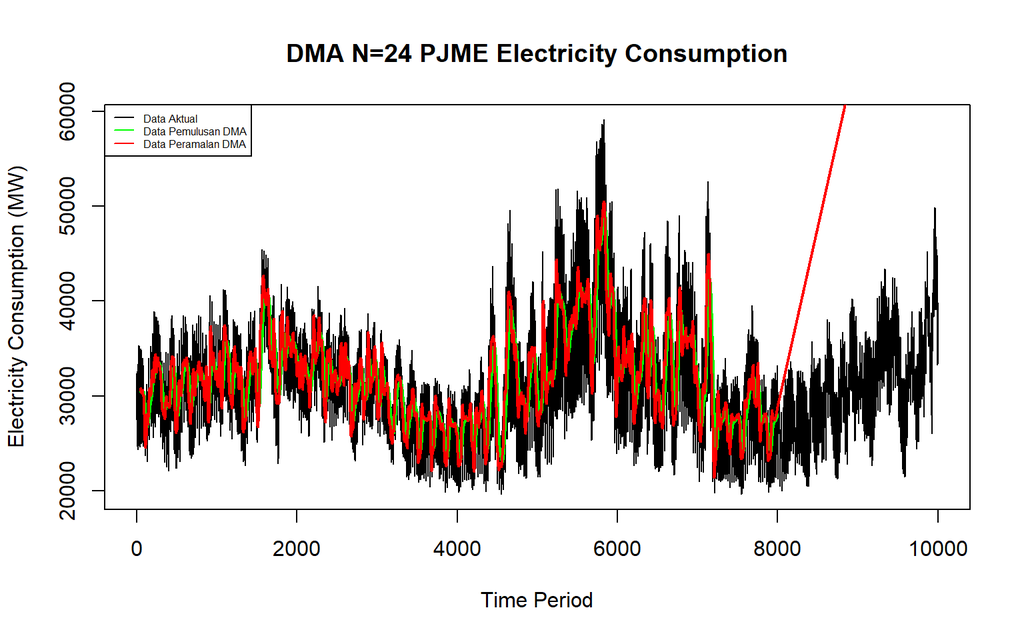

```r
ts.plot(
  data3.ts,
  xlab = "Time Period",
  ylab = "Electricity Consumption (MW)",
  main = "DMA N=24 PJME Electricity Consumption"
)

lines(data.gab2[,3], col = "green", lwd = 2)
lines(data.gab2[,6], col = "red", lwd = 2)

legend(
  "topleft",
  c("Data Aktual", "Data Pemulusan DMA", "Data Peramalan DMA"),
  lty = 1,
  col = c("black", "green", "red"),
  cex = 0.5
)
```

Selanjutnya perhitungan akurasi dilakukan baik pada data latih maupun data uji. Perhitungan akurasi dilakukan dengan ukuran akurasi SSE, MSE dan MAPE.

### a. Akurasi Data Latih

```r
# Menghitung nilai keakuratan data latih
error_train.dma <- train_ma.ts - data.ramal2[1:length(train_ma.ts)]

SSE_train.dma <- sum(
  error_train.dma[48:length(train_ma.ts)]^2
)

MSE_train.dma <- mean(
  error_train.dma[48:length(train_ma.ts)]^2
)

MAPE_train.dma <- mean(
  abs(
    (error_train.dma[48:length(train_ma.ts)] /
       train_ma.ts[48:length(train_ma.ts)]) * 100
  )
)

akurasi_train.dma <- matrix(
  c(SSE_train.dma, MSE_train.dma, MAPE_train.dma)
)

row.names(akurasi_train.dma) <- c("SSE", "MSE", "MAPE")

colnames(akurasi_train.dma) <- c("Akurasi m = 24")

akurasi_train.dma
```

```
##      Akurasi m = 24
## SSE    1.643281e+11
## MSE    2.066241e+07
## MAPE   1.200839e+01
```

Berdasarkan hasil perhitungan, metode DMA dengan m = 24 menghasilkan nilai MAPE sekitar **12%** pada data latih. Hal ini menunjukkan bahwa rata-rata kesalahan absolut relatif hasil peramalan terhadap nilai aktual berada di sekitar 12%, sehingga performa model pada data latih dapat dikategorikan **cukup baik**.

### b. Akurasi Data Uji

```r
# Menghitung nilai keakuratan data uji
error_test.dma <- test_ma.ts - data.gab2[8001:10000, 6]

SSE_test.dma <- sum(
  error_test.dma^2
)

MSE_test.dma <- mean(
  error_test.dma^2
)

MAPE_test.dma <- mean(
  abs(
    (error_test.dma / test_ma.ts) * 100
  )
)

akurasi_test.dma <- matrix(
  c(SSE_test.dma, MSE_test.dma, MAPE_test.dma)
)

row.names(akurasi_test.dma) <- c("SSE", "MSE", "MAPE")

colnames(akurasi_test.dma) <- c("Akurasi m = 24")

akurasi_test.dma
```

```
##      Akurasi m = 24
## SSE    3.259243e+12
## MSE    1.629621e+09
## MAPE   1.123077e+02
```

Berdasarkan hasil perhitungan pada data uji, metode DMA dengan m = 24 menghasilkan nilai MAPE sebesar **112.3%**. Nilai tersebut menunjukkan bahwa kesalahan absolut relatif hasil peramalan sangat besar dibandingkan nilai aktual. Dengan demikian, performa DMA pada data uji tergolong **kurang baik**.

Jika dibandingkan dengan SMA, DMA memiliki performa yang lebih baik pada data latih, tetapi SMA memberikan hasil yang jauh lebih baik pada data uji. Hal ini menunjukkan bahwa meskipun DMA mampu mengikuti pola tertentu pada data latih, hasil peramalannya kurang mampu mempertahankan akurasi ketika digunakan untuk meramalkan data di luar periode pelatihan.

# **Exponential Smoothing**

Metode Exponential Smoothing merupakan metode pemulusan deret waktu dengan memberikan bobot yang menurun secara eksponensial pada data historis, di mana nilai terbaru mendapat bobot lebih besar dibanding nilai yang lebih lama. Metode ini menggunakan satu atau lebih parameter pemulusan yang secara langsung menentukan besar kecilnya bobot setiap pengamatan. Pemilihan parameter yang tepat akan sangat berpengaruh terhadap hasil ramalan. Secara umum, Exponential Smoothing dibedakan menjadi dua jenis, yaitu model tunggal (single) yang digunakan untuk data tanpa tren maupun musiman, serta model ganda (double) yang mampu menangkap adanya tren pada data.

## 1. Pembagian Data

Pembagian data latih dan data uji dilakukan dengan perbandingan 80% data latih dan 20% data uji.

```r
# Jumlah observasi
n <- nrow(data3)

# Hitung batas 80%
n_train <- floor(0.8 * n)

# Bagi data training dan testing
training_es <- data3[1:n_train, ]
testing_es <- data3[(n_train + 1):n, ]

# Ubah ke time series
train_es.ts <- ts(training_es$PJME_MW)
test_es.ts <- ts(testing_es$PJME_MW)

# Cek
length(train_es.ts)
```

```
## [1] 8000
```

```r
length(test_es.ts)
```

```
## [1] 2000
```

## 2. Eksplorasi

Eksplorasi dilakukan dengan membuat plot data deret waktu untuk keseluruhan data, data latih, dan data uji.

```r
# Eksplorasi keseluruhan data
plot(data3.ts, col="red",main="Plot Semua Data")
```

[output not shown]

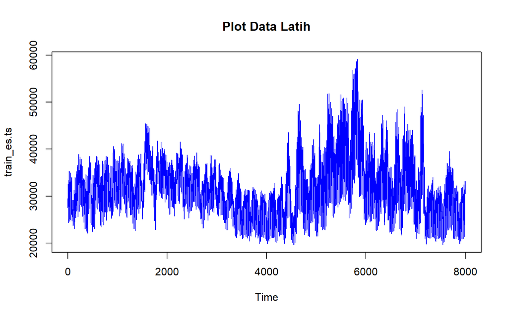

```r
# Eksplorasi data latih
plot(train_es.ts, col="blue",main="Plot Data Latih")
```

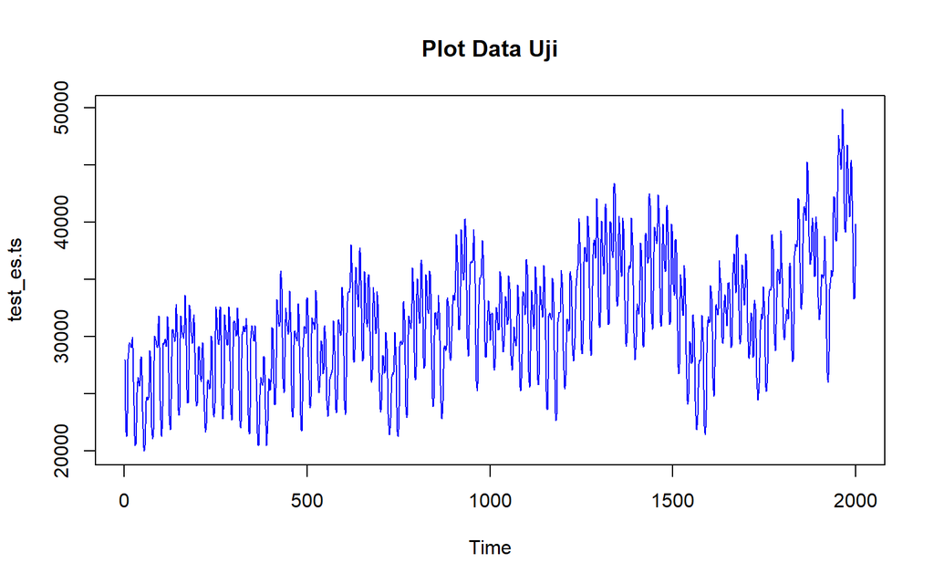

```r
# Eksplorasi data uji
plot(test_es.ts, col="blue",main="Plot Data Uji")
```

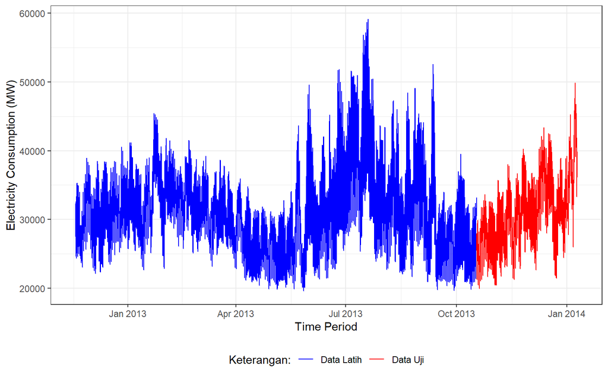

```r
ggplot() +
  geom_line(data = training_es,
            aes(x = Datetime,
                y = PJME_MW,
                col = "Data Latih")) +

  geom_line(data = testing_es,
            aes(x = Datetime,
                y = PJME_MW,
                col = "Data Uji")) +

  labs(x = "Time Period",
       y = "Electricity Consumption (MW)",
       color = "Legend") +

  scale_colour_manual(name="Keterangan:",
                      breaks = c("Data Latih", "Data Uji"),
                      values = c("blue", "red")) +

  theme_bw() + theme(legend.position = "bottom",
                     plot.caption = element_text(hjust=0.5, size=12))
```

## 3. **Single Exponential Smoothing**

Single Exponential Smoothing (SES) adalah metode peramalan deret waktu yang dikembangkan untuk mengatasi kelemahan Moving Average. Jika pada Moving Average setiap data periode sebelumnya dianggap memiliki bobot yang sama, maka SES memberikan bobot yang semakin mengecil secara eksponensial terhadap data lama, sehingga data terbaru diberi bobot lebih besar.

Single Exponential Smoothing merupakan metode pemulusan yang tepat digunakan untuk data dengan pola stasioner atau konstan.

Nilai pemulusan pada periode ke-t didapat dari persamaan:

$$\tilde{y}_T=\lambda
y_t+(1-\lambda)\tilde{y}_{T-1}$$

Nilai parameter $\lambda$ adalah nilai antara 0 dan 1.

Nilai pemulusan periode ke-t bertindak sebagai nilai ramalan pada periode ke-$(T+\tau)$.

$$\tilde{y}_{T+\tau}(T)=\tilde{y}_T$$

Pemulusan dengan metode SES dapat dilakukan dengan dua fungsi dari *packages* berbeda, yaitu (1) fungsi `ses()` dari *packages* `forecast` dan (2) fungsi `HoltWinters` dari *packages* `stats` .

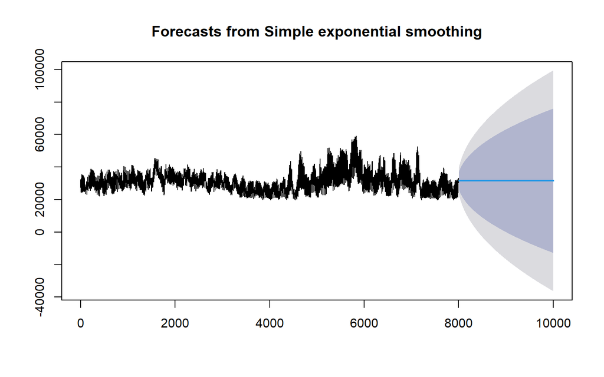

```r
# Cara 1 (fungsi ses)
ses.1 <- ses(train_es.ts, h = 2000, alpha = 0.2)
plot(ses.1)
```

```r
ses.1
```

```
##       Point Forecast         Lo 80    Hi 80         Lo 95    Hi 95
##  8001       31501.33  26570.518799 36432.14  23960.306256 39042.35
##  8002       31501.33  26472.869540 36529.79  23810.964602 39191.69
##  8003       31501.33  26377.080778 36625.57  23664.468332 39338.19
##  8004       31501.33  26283.050057 36719.61  23520.660753 39481.99
##  8005       31501.33  26190.683990 36811.97  23379.399045 39623.26
##  8006       31501.33  26099.897180 36902.76  23240.552601 39762.10
##  8007       31501.33  26010.611288 36992.04  23104.001613 39898.65
##  8008       31501.33  25922.754248 37079.90  22969.635865 40033.02
##  8009       31501.33  25836.259580 37166.40  22837.353685 40165.30
##  8010       31501.33  25751.065805 37251.59  22707.061050 40295.59
##  8011       31501.33  25667.115936 37335.54  22578.670805 40423.98
##  8012       31501.33  25584.357026 37418.30  22452.101974 40550.55
##  8013       31501.33  25502.739782 37499.92  22327.279172 40675.38
##  8014       31501.33  25422.218221 37580.44  22204.132071 40798.52
```

[output cut: 1986 more lines]

```r
ses.2 <- ses(train_es.ts, h = 2000, alpha = 0.2)
plot(ses.2)
ses.2
```

[output not shown]

```
##       Point Forecast         Lo 80    Hi 80         Lo 95    Hi 95
##  8001       31501.33  26570.518799 36432.14  23960.306256 39042.35
##  8002       31501.33  26472.869540 36529.79  23810.964602 39191.69
##  8003       31501.33  26377.080778 36625.57  23664.468332 39338.19
##  8004       31501.33  26283.050057 36719.61  23520.660753 39481.99
##  8005       31501.33  26190.683990 36811.97  23379.399045 39623.26
##  8006       31501.33  26099.897180 36902.76  23240.552601 39762.10
##  8007       31501.33  26010.611288 36992.04  23104.001613 39898.65
##  8008       31501.33  25922.754248 37079.90  22969.635865 40033.02
##  8009       31501.33  25836.259580 37166.40  22837.353685 40165.30
##  8010       31501.33  25751.065805 37251.59  22707.061050 40295.59
##  8011       31501.33  25667.115936 37335.54  22578.670805 40423.98
##  8012       31501.33  25584.357026 37418.30  22452.101974 40550.55
##  8013       31501.33  25502.739782 37499.92  22327.279172 40675.38
##  8014       31501.33  25422.218221 37580.44  22204.132071 40798.52
```

[output cut: 1986 more lines]

Pada fungsi `ses()` , terdapat beberapa argumen yang umum digunakan, yaitu

- `y` : nilai data deret waktu
- `alpha` : parameter pemulusan utama (0–1), mengatur bobot data terbaru vs data lama.
- `beta` : parameter pemulusan tren.
- `gamma` : parameter pemulusan musiman.
- `h` : jumlah periode ke depan yang ingin diramalkan (forecast horizon).

Untuk mendapatkan gambar hasil pemulusan pada data latih dengan fungsi `ses()` , perlu digunakan fungsi `autoplot()` dan `autolayer()` dari *library packages* `ggplot2` .

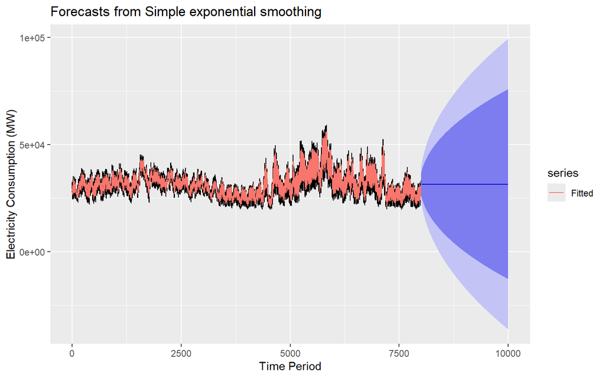

```r
autoplot(ses.1) +
  autolayer(fitted(ses.1),
            series="Fitted") +

  ylab("Electricity Consumption (MW)") + xlab("Time Period")
```

Selanjutnya akan digunakan fungsi `HoltWinters()` dengan nilai inisialisasi parameter dan panjang periode peramalan yang sama dengan fungsi `ses()` .

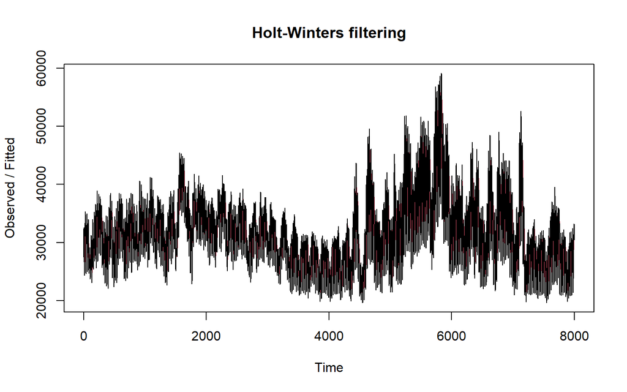

```r
# Cara 2 (fungsi HoltWinters)
ses1 <- HoltWinters(
  train_es.ts,
  gamma = FALSE,
  beta = FALSE,
  alpha = 0.2
)

plot(ses1)
```

```r
# Ramalan
ramalan1 <- forecast(ses1, h = 2000)
ramalan1
```

```
##       Point Forecast         Lo 80    Hi 80         Lo 95    Hi 95
##  8001       31501.33  26570.417563 36432.24  23960.151429 39042.50
##  8002       31501.33  26472.766299 36529.89  23810.806709 39191.85
##  8003       31501.33  26376.975571 36625.68  23664.307431 39338.35
##  8004       31501.33  26282.942918 36719.71  23520.496900 39482.16
##  8005       31501.33  26190.574956 36812.08  23379.232291 39623.42
##  8006       31501.33  26099.786281 36902.87  23240.382996 39762.27
##  8007       31501.33  26010.498557 36992.16  23103.829205 39898.83
##  8008       31501.33  25922.639712 37080.02  22969.460698 40033.19
##  8009       31501.33  25836.143268 37166.51  22837.175802 40165.48
##  8010       31501.33  25750.947745 37251.71  22706.880492 40295.77
##  8011       31501.33  25666.996152 37335.66  22578.487611 40424.17
##  8012       31501.33  25584.235543 37418.42  22451.916182 40550.74
##  8013       31501.33  25502.616623 37500.04  22327.090816 40675.56
##  8014       31501.33  25422.093409 37580.56  22203.941187 40798.71
```

[output cut: 1986 more lines]

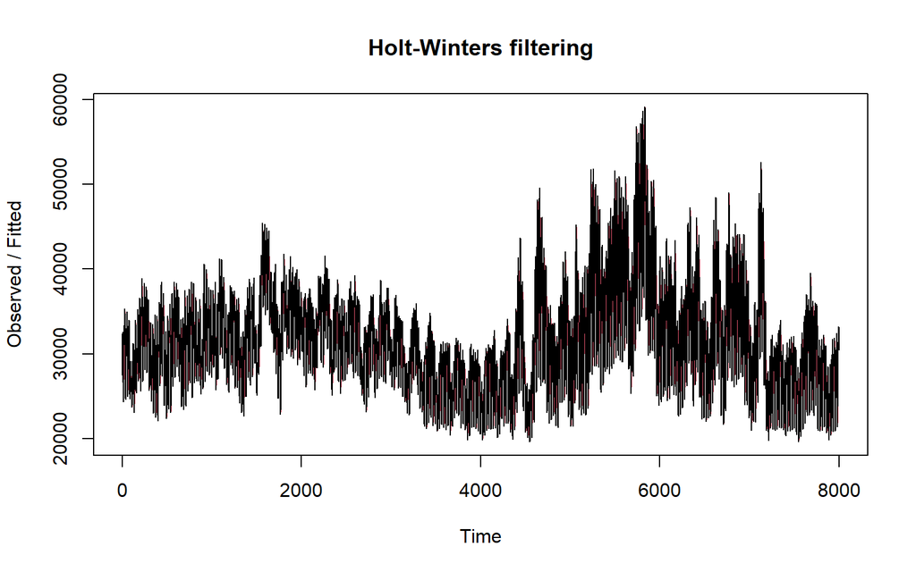

```r
ses2 <- HoltWinters(
  train_es.ts,
  gamma = FALSE,
  beta = FALSE,
  alpha = 0.7
)

plot(ses2)
```

```r
# Ramalan
ramalan2 <- forecast(ses2, h = 2000)
ramalan2
```

```
##       Point Forecast        Lo 80     Hi 80        Lo 95     Hi 95
##  8001       31058.89  28610.23162  33507.55  27313.98928  34803.79
##  8002       31058.89  28069.92116  34047.86  26487.65573  35630.13
##  8003       31058.89  27613.32156  34504.46  25789.34690  36328.44
##  8004       31058.89  27210.52031  34907.26  25173.31556  36944.47
##  8005       31058.89  26846.05761  35271.73  24615.91796  37501.87
##  8006       31058.89  26510.70747  35607.08  24103.04418  38014.74
##  8007       31058.89  26198.44023  35919.34  23625.47264  38492.31
##  8008       31058.89  25905.05845  36212.72  23176.78392  38941.00
##  8009       31058.89  25627.50091  36490.28  22752.29630  39365.49
##  8010       31058.89  25363.45364  36754.33  22348.47086  39769.31
##  8011       31058.89  25111.11704  37006.67  21962.55533  40155.23
##  8012       31058.89  24869.05874  37248.72  21592.35910  40525.42
##  8013       31058.89  24636.11654  37481.67  21236.10474  40881.68
##  8014       31058.89  24411.33203  37706.45  20892.32651  41225.46
```

[output cut: 1986 more lines]

Fungsi `HoltWinters` memiliki argumen yang sama dengan fungsi `ses()` . Argumen-argumen kedua fungsi dapat dilihat lebih lanjut dengan `?ses()` atau `?HoltWinters` .

Nilai parameter $\alpha$ dari kedua fungsi dapat dioptimalkan menyesuaikan dari *error*-nya paling minimumnya. Caranya adalah dengan membuat parameter $\alpha =$ `NULL` .

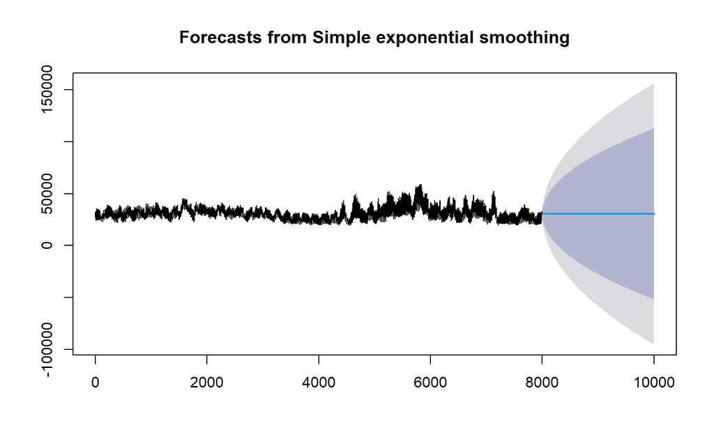

```r
# SES
ses.opt <- ses(train_es.ts, h = 2000, alpha = NULL)
plot(ses.opt)
```

```r
ses.opt
```

```
##       Point Forecast        Lo 80     Hi 80        Lo 95     Hi 95
##  8001       30469.17  28632.49208  32305.86  27660.21154  33278.14
##  8002       30469.17  27871.84351  33066.50  26496.89995  34441.45
##  8003       30469.17  27288.15989  33650.19  25604.23289  35334.11
##  8004       30469.17  26796.08595  34142.26  24851.67074  36086.68
##  8005       30469.17  26362.55729  34575.79  24188.64587  36749.70
##  8006       30469.17  25970.61581  34967.73  23589.22310  37349.12
##  8007       30469.17  25610.18740  35328.16  23037.99542  37900.35
##  8008       30469.17  25274.70813  35663.64  22524.92414  38413.42
##  8009       30469.17  24959.61861  35978.73  22043.03630  38895.31
##  8010       30469.17  24661.59916  36276.75  21587.25489  39351.09
##  8011       30469.17  24378.14367  36560.20  21153.74713  39784.60
##  8012       30469.17  24107.30514  36831.04  20739.53534  40198.81
##  8013       30469.17  23847.53521  37090.81  20342.25151  40596.10
##  8014       30469.17  23597.57846  37340.77  19959.97566  40978.37
```

[output cut: 1986 more lines]

```r
# Lambda optimum Holt Winter
HWopt <- HoltWinters(
  train_es.ts,
  gamma = FALSE,
  beta = FALSE,
  alpha = NULL
)

HWopt
```

```
## Holt-Winters exponential smoothing without trend and without seasonal component.
##
## Call:
## HoltWinters(x = train_es.ts, alpha = NULL, beta = FALSE, gamma = FALSE)
##
## Smoothing parameters:
##  alpha: 0.9999551
##  beta : FALSE
##  gamma: FALSE
##
## Coefficients:
##       [,1]
## a 30469.08
```

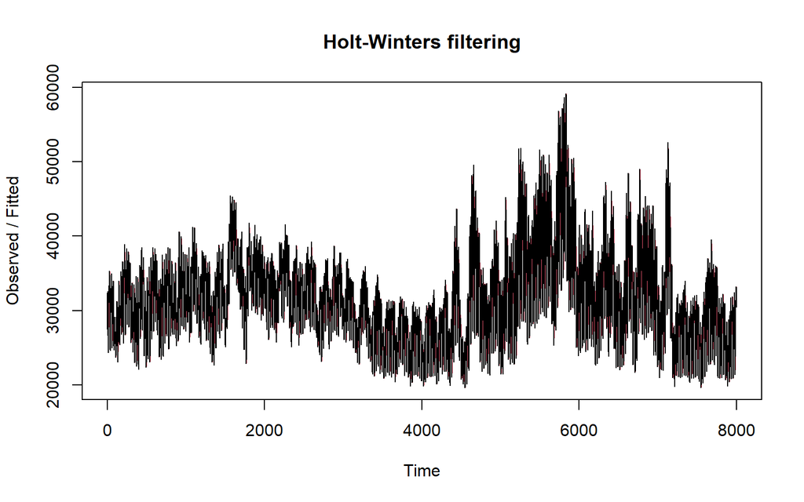

```r
plot(HWopt)
```

```r
# Ramalan
ramalanopt <- forecast(HWopt, h = 2000)
ramalanopt
```

```
##       Point Forecast        Lo 80     Hi 80        Lo 95     Hi 95
##  8001       30469.08  28632.78680  32305.37  27660.71296  33277.44
##  8002       30469.08  27872.22837  33065.93  26497.53923  34440.62
##  8003       30469.08  27288.62353  33649.53  25604.99266  35333.16
##  8004       30469.08  26796.61926  34141.54  24852.53705  36085.62
##  8005       30469.08  26363.15352  34575.00  24189.60841  36748.55
##  8006       30469.08  25971.26982  34966.89  23590.27401  37347.88
##  8007       30469.08  25610.89511  35327.26  23039.12845  37899.03
##  8008       30469.08  25275.46619  35662.69  22526.13419  38412.02
##  8009       30469.08  24960.42425  35977.73  22044.31911  38893.84
##  8010       30469.08  24662.45000  36275.71  21588.60682  39349.55
##  8011       30469.08  24379.03766  36559.12  21155.16506  39782.99
##  8012       30469.08  24108.24048  36829.92  20741.01651  40197.14
##  8013       30469.08  23848.51031  37089.65  20343.79349  40594.36
##  8014       30469.08  23598.59191  37339.56  19961.57628  40976.58
```

[output cut: 1986 more lines]

Setelah dilakukan peramalan, akan dilakukan perhitungan keakuratan hasil peramalan. Perhitungan akurasi ini dilakukan baik pada data latih dan data uji.

### a. Akurasi Data Latih

Perhitungan akurasi data dapat dilakukan dengan cara langsung maupun manual. Secara langsung, nilai akurasi dapat diambil dari objek yang tersimpan pada hasil SES, yaitu *sum of squared errors* (SSE). Nilai akurasi lain dapat dihitung pula dari nilai SSE tersebut.

```r
# Keakuratan Metode
# Pada data training

# SES dengan alpha = 0.2
SSE1 <- ses1$SSE
MSE1 <- ses1$SSE/length(train_es.ts)
RMSE1 <- sqrt(MSE1)

akurasi1 <- matrix(c(SSE1,MSE1,RMSE1))
row.names(akurasi1) <- c("SSE", "MSE", "RMSE")
colnames(akurasi1) <- c("Akurasi lamda=0.2")
akurasi1
```

```
##      Akurasi lamda=0.2
## SSE       1.184032e+11
## MSE       1.480040e+07
## RMSE      3.847129e+03
```

```r
# SES dengan alpha = 0.7
SSE2 <- ses2$SSE
MSE2 <- ses2$SSE/length(train_es.ts)
RMSE2<-sqrt(MSE2)

akurasi2 <- matrix(c(SSE2,MSE2,RMSE2))
row.names(akurasi2) <- c("SSE", "MSE", "RMSE")
colnames(akurasi2) <- c("Akurasi lamda=0.7")
akurasi2
```

```
##      Akurasi lamda=0.7
## SSE       2.919889e+10
## MSE       3.649861e+06
## RMSE      1.910461e+03
```

Berdasarkan hasil evaluasi pada data latih, model SES dengan parameter α = 0,7 menghasilkan nilai SSE sebesar **2,92 × 10¹⁰**, MSE sebesar **3,65 × 10⁶**, dan RMSE sebesar **1.910,461**. Nilai tersebut lebih kecil dibandingkan model dengan α = 0,2 yang menghasilkan SSE sebesar **1,18 × 10¹¹**, MSE sebesar **1,48 × 10⁷**, dan RMSE sebesar **3.847,129**. Dengan demikian, berdasarkan data latih, model SES dengan **α = 0,7 memiliki performa yang lebih baik**.

```r
# Cara Manual
# Alpha = 0.2
fitted1 <- ramalan1$fitted
sisaan1 <- ramalan1$residuals
head(sisaan1)
```

```
## Time Series:
## Start = 1
## End = 6
## Frequency = 1
## [1]       NA -150.000  151.000 1809.800 4319.840 3722.872
```

```r
resid1 <- training_es$PJME_MW - ramalan1$fitted
head(resid1)
```

```
## Time Series:
## Start = 1
## End = 6
## Frequency = 1
## [1]       NA -150.000  151.000 1809.800 4319.840 3722.872
```

```r
SSE.1 = sum(sisaan1[2:length(train_es.ts)]^2)
SSE.1
```

```
## [1] 118403235111
```

```r
MSE.1 = SSE.1/length(train_es.ts)
MSE.1
```

```
## [1] 14800404
```

```r
MAPE.1 = sum(abs(sisaan1[2:length(train_es.ts)]/train_es.ts[2:length(train_es.ts)])*
               100)/length(train_es.ts)
MAPE.1
```

```
## [1] 10.15972
```

```r
akurasi.1 <- matrix(c(SSE.1,MSE.1,MAPE.1))
row.names(akurasi.1)<- c("SSE", "MSE", "MAPE")
colnames(akurasi.1) <- c("Akurasi lamda=0.2")
akurasi.1
```

```
##      Akurasi lamda=0.2
## SSE       1.184032e+11
## MSE       1.480040e+07
## MAPE      1.015972e+01
```

```r
# Alpha = 0.7
fitted2 <- ramalan2$fitted
sisaan2 <- ramalan2$residuals
head(sisaan2)
```

```
## Time Series:
## Start = 1
## End = 6
## Frequency = 1
## [1]       NA -150.000  226.000 1756.800 3399.040 1286.712
```

```r
resid2<-training_es$PJME_MW - ramalan2$fitted
head(resid2)
```

```
## Time Series:
## Start = 1
## End = 6
## Frequency = 1
## [1]       NA -150.000  226.000 1756.800 3399.040 1286.712
```

```r
SSE.2 = sum(sisaan2[2:length(train_es.ts)]^2)
SSE.2
```

```
## [1] 29198885382
```

```r
MSE.2 = SSE.2/length(train_es.ts)
MSE.2
```

```
## [1] 3649861
```

```r
MAPE.2 = sum(abs(sisaan2[2:length(train_es.ts)]/train_es.ts[2:length(train_es.ts)])*
               100)/length(train_es.ts)
MAPE.2
```

```
## [1] 4.779911
```

```r
akurasi.2 <- matrix(c(SSE.2,MSE.2,MAPE.2))
row.names(akurasi.2)<- c("SSE", "MSE", "MAPE")
colnames(akurasi.2) <- c("Akurasi lamda=0.7")
akurasi.2
```

```
##      Akurasi lamda=0.7
## SSE       2.919889e+10
## MSE       3.649861e+06
## MAPE      4.779911e+00
```

Berdasarkan hasil perhitungan akurasi pada data latih, model SES dengan α = 0.7 menghasilkan nilai kesalahan yang lebih kecil dibandingkan model dengan α = 0.2. Hal ini menunjukkan bahwa pada data latih, model dengan α = 0.7 mampu memberikan hasil pemulusan yang lebih mendekati nilai aktual.

Nilai MAPE sebesar 4.78% menunjukkan bahwa rata-rata kesalahan absolut relatif model terhadap data aktual sekitar 4.78%, sehingga performanya pada data latih dapat dikategorikan sangat baik.

### b. Akurasi Data Uji

Akurasi data uji dapat dihitung dengan cara yang hampir sama dengan perhitungan akurasi data latih.

```r
# Jumlah observasi uji
n_test <- nrow(testing_es)

# error (ramalan - aktual), samakan panjang dan tipe numeric
e1   <- as.numeric(ramalan1$mean)[1:n_test] - as.numeric(testing_es$PJME_MW)
e2   <- as.numeric(ramalan2$mean)[1:n_test] - as.numeric(testing_es$PJME_MW)
eopt <- as.numeric(ramalanopt$mean)[1:n_test] - as.numeric(testing_es$PJME_MW)

# SSE / MSE / RMSE untuk masing-masing model (abaikan NA)
SSEtesting1  <- sum(e1^2,  na.rm = TRUE)
MSEtesting1  <- mean(e1^2, na.rm = TRUE)
RMSEtesting1 <- sqrt(MSEtesting1)

SSEtesting2  <- sum(e2^2,  na.rm = TRUE)
MSEtesting2  <- mean(e2^2, na.rm = TRUE)
RMSEtesting2 <- sqrt(MSEtesting2)

SSEtestingopt  <- sum(eopt^2,  na.rm = TRUE)
MSEtestingopt  <- mean(eopt^2, na.rm = TRUE)
RMSEtestingopt <- sqrt(MSEtestingopt)

# Tabel ringkas
akurasitesting_SSE <- matrix(c(SSEtesting1, SSEtesting2, SSEtestingopt),
                             nrow = 3,
                             dimnames = list(c("SSE1","SSE2","SSEopt"), "Nilai"))
akurasitesting_MSE <- matrix(c(MSEtesting1, MSEtesting2, MSEtestingopt),
                             nrow = 3,
                             dimnames = list(c("MSE1","MSE2","MSEopt"), "Nilai"))
akurasitesting_RMSE <- matrix(c(RMSEtesting1, RMSEtesting2, RMSEtestingopt),
                              nrow = 3,
                              dimnames = list(c("RMSE1","RMSE2","RMSEopt"), "Nilai"))

akurasitesting_SSE
```

```
##              Nilai
## SSE1   52442084293
## SSE2   52545752027
## SSEopt 53901622106
```

```r
akurasitesting_MSE
```

```
##           Nilai
## MSE1   26221042
## MSE2   26272876
## MSEopt 26950811
```

```r
akurasitesting_RMSE
```

```
##            Nilai
## RMSE1   5120.649
## RMSE2   5125.707
## RMSEopt 5191.417
```

Berbeda dengan hasil pada data latih, pada data uji model SES dengan α = 0.2 menghasilkan nilai kesalahan yang lebih kecil dibandingkan model dengan α = 0.7. Hal ini menunjukkan bahwa model dengan α = 0.2 memberikan kemampuan generalisasi yang lebih baik terhadap data yang belum digunakan dalam proses pemodelan.

```r
accuracy(ramalan1, testing_es$PJME_MW)
```

```
##                       ME     RMSE      MAE       MPE     MAPE     MASE
## Training set    2.408631 3847.370 3130.913 -1.319196 10.16099 2.848418
## Test set     -162.640166 5120.649 4017.725 -3.271763 13.38248 3.655215
##                   ACF1
## Training set 0.9383228
## Test set            NA
```

```r
accuracy(ramalan2, testing_es$PJME_MW)
```

```
##                       ME     RMSE      MAE       MPE      MAPE     MASE
## Training set   0.6091639 1910.580 1490.712 -0.241170  4.780508 1.356209
## Test set     279.7958015 5125.707 4002.894 -1.821312 13.147721 3.641722
##                   ACF1
## Training set 0.8794252
## Test set            NA
```

```r
accuracy(ramalanopt, testing_es$PJME_MW)
```

```
##                       ME     RMSE      MAE        MPE      MAPE     MASE
## Training set   0.3526947 1432.776 1099.219 -0.1038039  3.514265 1.000039
## Test set     869.6095274 5191.417 4047.164  0.1122923 13.041331 3.681997
##                   ACF1
## Training set 0.8351769
## Test set            NA
```

- Pada data latih, SES dengan α = 0.2 menghasilkan MAPE sebesar **10.16%** dan RMSE sebesar **3847.37**. Pada data uji, nilai MAPE meningkat menjadi **13.38%** dengan RMSE sebesar **5120.65**. Peningkatan nilai error pada data uji menunjukkan bahwa performa model sedikit menurun ketika digunakan untuk meramalkan data yang belum digunakan dalam proses pelatihan.
- Pada data latih, SES dengan α = 0.7 menghasilkan MAPE sebesar **4.78%** dan RMSE sebesar **1910.58**, yang lebih kecil dibandingkan SES dengan α = 0.2. Hal ini menunjukkan bahwa α = 0.7 memberikan hasil pemulusan yang lebih baik pada data latih. Pada data uji, model menghasilkan MAPE sebesar **13.15%** dan RMSE sebesar **5125.71**. Meskipun MAPE pada data uji meningkat dibandingkan data latih, model masih menghasilkan performa yang relatif baik.
- Model SES dengan parameter α optimum menghasilkan MAPE sebesar **3.51%** dan RMSE sebesar **1432.78** pada data latih. Nilai tersebut merupakan yang paling kecil dibandingkan kedua model SES lainnya. Pada data uji, model optimum menghasilkan MAPE sebesar **13.04%**, yang juga merupakan nilai MAPE terkecil dibandingkan α = 0.2 dan α = 0.7. Namun, RMSE model optimum sebesar **5191.42** sedikit lebih besar dibandingkan kedua model lainnya.

**Kesimpulan:**

Berdasarkan hasil evaluasi pada data uji, ketiga model SES menghasilkan nilai MAPE yang relatif berdekatan, yaitu 13.38% untuk α = 0.2, 13.15% untuk α = 0.7, dan 13.04% untuk model dengan α optimum. Berdasarkan MAPE, model SES dengan α optimum memberikan hasil terbaik. Sementara itu, berdasarkan RMSE, model dengan α = 0.2 memberikan nilai terkecil, yaitu 5120.65. Dengan demikian, performa ketiga model SES pada data uji relatif serupa, dengan model α optimum unggul berdasarkan MAPE.

## 4. Double Exponential Smoothing (DES)

Metode pemulusan *Double Exponential Smoothing* (DES) digunakan untuk data yang memiliki pola tren. Metode DES adalah metode semacam SES, hanya saja dilakukan dua kali, yaitu pertama untuk tahapan ‘level’ dan kedua untuk tahapan ‘tren’. Pemulusan menggunakan metode ini akan menghasilkan peramalan tidak konstan untuk periode berikutnya.

Pemulusan dengan metode DES kali ini akan menggunakan fungsi `HoltWinters()` . Jika sebelumnya nilai argumen `beta` dibuat `FALSE` , kali ini argumen tersebut akan diinisialisasi bersamaan dengan nilai `alpha` .

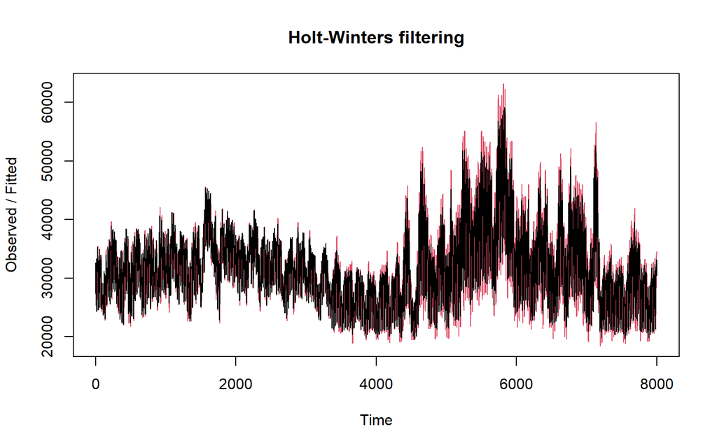

```r
# Lamda=0.2 dan gamma=0.2
des.1 <- HoltWinters(
  train_es.ts,
  gamma = FALSE,
  beta = 0.2,
  alpha = 0.2
)

plot(des.1)
```

```r
ramalandes1 <- forecast(des.1, h = 2000)
ramalandes1
```

```
##       Point Forecast         Lo 80       Hi 80         Lo 95       Hi 95
##  8001       34079.69  2.735395e+04    40805.43  2.379356e+04    44365.82
##  8002       34455.85  2.753912e+04    41372.58  2.387763e+04    45034.07
##  8003       34832.01  2.766350e+04    42000.52  2.386871e+04    45795.30
##  8004       35208.17  2.772354e+04    42692.80  2.376141e+04    46654.92
##  8005       35584.33  2.771780e+04    43450.85  2.355352e+04    47615.14
##  8006       35960.49  2.764665e+04    44274.33  2.324557e+04    48675.41
##  8007       36336.65  2.751183e+04    45161.47  2.284025e+04    49833.05
##  8008       36712.81  2.731601e+04    46109.61  2.234165e+04    51083.97
##  8009       37088.97  2.706243e+04    47115.51  2.175470e+04    52423.24
##  8010       37465.13  2.675451e+04    48175.75  2.108465e+04    53845.61
##  8011       37841.29  2.639567e+04    49286.91  2.033673e+04    55345.85
##  8012       38217.45  2.598918e+04    50445.72  1.951592e+04    56918.98
##  8013       38593.61  2.553806e+04    51649.17  1.862686e+04    58560.36
##  8014       38969.77  2.504506e+04    52894.48  1.767376e+04    60265.78
```

[output cut: 1986 more lines]

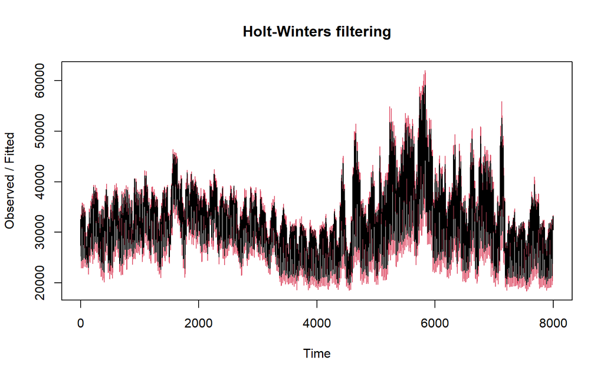

```r
# Lamda=0.6 dan gamma=0.3
des.2 <- HoltWinters(
  train_es.ts,
  gamma = FALSE,
  beta = 0.3,
  alpha = 0.6
)

plot(des.2)
```

```r
ramalandes2 <- forecast(des.2, h = 2000)
ramalandes2
```

```
##       Point Forecast         Lo 80       Hi 80         Lo 95       Hi 95
##  8001     31110.3234  2.848074e+04    33739.90     27088.728    35131.92
##  8002     30824.1312  2.748923e+04    34159.04     25723.835    35924.43
##  8003     30537.9391  2.635534e+04    34720.54     24141.201    36934.68
##  8004     30251.7470  2.510583e+04    35397.67     22381.742    38121.75
##  8005     29965.5549  2.375841e+04    36172.70     20472.546    39458.56
##  8006     29679.3627  2.232500e+04    37033.73     18431.831    40926.89
##  8007     29393.1706  2.081397e+04    37972.37     16272.413    42513.93
##  8008     29106.9785  1.923152e+04    38982.44     14003.761    44210.20
##  8009     28820.7864  1.758242e+04    40059.16     11633.184    46008.39
##  8010     28534.5942  1.587050e+04    41198.69      9166.533    47902.66
##  8011     28248.4021  1.409892e+04    42397.89      6608.634    49888.17
##  8012     27962.2100  1.227034e+04    43654.08      3963.563    51960.86
##  8013     27676.0179  1.038706e+04    44964.98      1234.834    54117.20
##  8014     27389.8257  8.451083e+03    46328.57     -1574.482    56354.13
```

[output cut: 1986 more lines]

Selanjutnya jika ingin membandingkan plot data latih dan data uji adalah sebagai berikut.

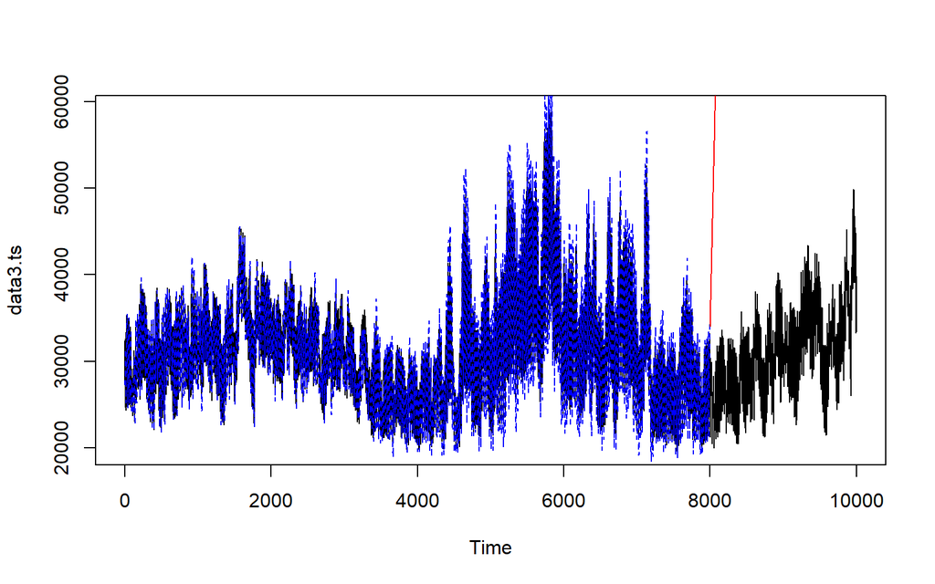

```r
plot(data3.ts)

lines(
  des.1$fitted[,1],
  lty=2, col="blue")

lines(
  ramalandes1$mean,
  col="red")
```

Untuk mendapatkan nilai parameter optimum dari DES, argumen `alpha` dan `beta` dapat dibuat `NULL` seperti berikut.

```r
# Lambda dan gamma optimum
des.opt <- HoltWinters(
  train_es.ts,
  gamma = FALSE)
des.opt
```

```
## Holt-Winters exponential smoothing with trend and without seasonal component.
##
## Call:
## HoltWinters(x = train_es.ts, gamma = FALSE)
##
## Smoothing parameters:
##  alpha: 1
##  beta : 1
##  gamma: FALSE
##
## Coefficients:
##    [,1]
## a 30469
## b -1737
```

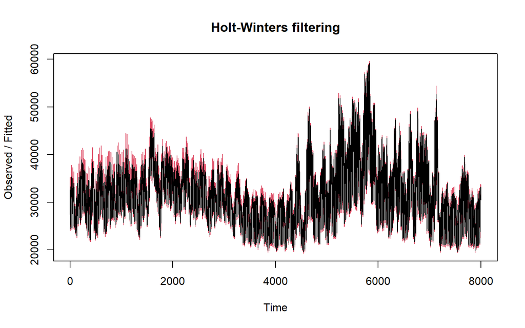

```r
# Plot
plot(des.opt)
```

```r
# Ramalan
ramalandesopt<- forecast(
  des.opt, h = 2000)
ramalandesopt
```

```
##       Point Forecast         Lo 80       Hi 80         Lo 95       Hi 95
##  8001          28732     27677.944    29786.06  2.711996e+04    30344.04
##  8002          26995     24638.058    29351.94  2.339037e+04    30599.63
##  8003          25258     21314.082    29201.92  1.922630e+04    31289.70
##  8004          23521     17747.696    29294.30  1.469149e+04    32350.51
##  8005          21784     13966.909    29601.09  9.828791e+03    33739.21
##  8006          20047      9991.944    30102.06  4.669118e+03    35424.88
##  8007          18310      5838.237    30781.76 -7.639148e+02    37383.91
##  8008          16573      1518.065    31627.94 -6.451537e+03    39597.54
##  8009          14836     -2958.519    32630.52 -1.237837e+04    42050.37
##  8010          13099     -7583.078    33781.08 -1.853151e+04    44729.51
##  8011          11362    -12348.410    35072.41 -2.489994e+04    47623.94
##  8012           9625    -17248.269    36498.27 -3.147412e+04    50724.12
##  8013           7888    -22277.169    38053.17 -3.824565e+04    54021.65
##  8014           6151    -27430.248    39732.25 -4.520709e+04    57509.09
```

[output cut: 1986 more lines]

Selanjutnya akan dilakukan perhitungan akurasi pada data latih maupun data uji dengan ukuran akurasi SSE, MSE dan MAPE.

### a. Akurasi Data Latih

```r
# Akurasi Data Training
ssedes.train1 <- des.1$SSE
msedes.train1 <- ssedes.train1/length(train_es.ts)
sisaandes1 <- ramalandes1$residuals
head(sisaandes1)
```

```
## Time Series:
## Start = 1
## End = 6
## Frequency = 1
## [1]       NA       NA  421.000 2158.960 4645.970 3844.738
```

```r
mapedes.train1 <- sum(abs(sisaandes1[3:length(train_es.ts)]/train_es.ts[3:length(train_es.ts)])
                      *100)/length(train_es.ts)

akurasides.1 <- matrix(c(ssedes.train1,msedes.train1,mapedes.train1))
row.names(akurasides.1)<- c("SSE", "MSE", "MAPE")
colnames(akurasides.1) <- c("Akurasi lamda=0.2 dan gamma=0.2")
akurasides.1
```

```
##      Akurasi lamda=0.2 dan gamma=0.2
## SSE                     2.202596e+11
## MSE                     2.753244e+07
## MAPE                    1.336714e+01
```

```r
ssedes.train2 <- des.2$SSE
msedes.train2 <- ssedes.train2/length(train_es.ts)
sisaandes2<-ramalandes2$residuals
head(sisaandes2)
```

```
## Time Series:
## Start = 1
## End = 6
## Frequency = 1
## [1]        NA        NA  421.0000 1931.6200 3371.1764  735.1872
```

```r
mapedes.train2 <- sum(abs(sisaandes2[3:length(train_es.ts)]/train_es.ts[3:length(train_es.ts)])
                      *100)/length(train_es.ts)

akurasides.2 <- matrix(c(ssedes.train2,msedes.train2,mapedes.train2))
row.names(akurasides.2) <- c("SSE", "MSE", "MAPE")
colnames(akurasides.2) <- c("Akurasi lamda=0.6 dan gamma=0.3")
akurasides.2
```

```
##      Akurasi lamda=0.6 dan gamma=0.3
## SSE                     3.366879e+10
## MSE                     4.208599e+06
## MAPE                    5.483485e+00
```

Berdasarkan hasil evaluasi pada data latih, model DES dengan parameter α = 0,6 dan β = 0,3 menghasilkan nilai SSE sebesar **3,37 × 10¹⁰**, MSE sebesar **4,21 × 10⁶**, dan MAPE sebesar **5,48%**. Nilai tersebut lebih kecil dibandingkan model DES dengan α = 0,2 dan β = 0,2 yang menghasilkan SSE sebesar **2,20 × 10¹¹**, MSE sebesar **2,75 × 10⁷**, dan MAPE sebesar **13,37%**. Dengan demikian, berdasarkan data latih, model DES dengan **α = 0,6 dan β = 0,3 memiliki performa peramalan yang lebih baik**.

### b. Akurasi Data Uji

```r
#Akurasi Data Testing
selisihdes1 <- ramalandes1$mean-testing_es$PJME_MW
selisihdes1
```

```
## Time Series:
## Start = 8001
## End = 10000
## Frequency = 1
##    [1]   6115.688   8902.849  11263.009  12816.169  13949.329  14699.490
##    [7]  14728.650  13489.810  10752.970   9448.130   9272.291   9263.451
##   [13]   9319.611   9501.771   9967.931  10350.092  10924.252  11397.412
##   [19]  11793.572  12217.732  11903.893  12065.053  13324.213  14898.373
##   [25]  17065.533  19483.694  21488.854  22906.014  23907.174  24538.335
##   [31]  24806.495  24526.655  23663.815  22782.975  21752.136  21181.296
##   [37]  21182.456  21557.616  22170.776  22829.937  23450.097  23771.257
##   [43]  23751.417  23516.577  22594.738  22757.898  23706.058  25123.218
##   [49]  26980.378  29077.539  30945.699  32322.859  33327.019  34044.180
##   [55]  34362.340  34305.500  33734.660  33209.820  32408.981  31920.141
##   [61]  32007.301  32280.461  32694.621  33189.782  33676.942  33915.102
```

[output cut: 323 more lines]

```r
SSEtestingdes1 <- sum(selisihdes1^2)
MSEtestingdes1 <- SSEtestingdes1/length(testing_es$PJME_MW)
MAPEtestingdes1 <- sum(abs(selisihdes1/testing_es$PJME_MW)*100)/length(testing_es$PJME_MW)

selisihdes2 <- ramalandes2$mean-testing_es$PJME_MW
selisihdes2
```

```
## Time Series:
## Start = 8001
## End = 10000
## Frequency = 1
##    [1]    3146.32336    5271.13123    6968.93911    7859.74698    8330.55486
##    [6]    8418.36273    7785.17061    5883.97849    2484.78636     517.59424
##   [11]    -320.59789    -991.79001   -1597.98214   -2078.17426   -2274.36639
##   [16]   -2554.55851   -2642.75063   -2831.94276   -3098.13488   -3336.32701
##   [21]   -4312.51913   -4813.71126   -4216.90338   -3305.09550   -1800.28763
##   [26]     -44.47975    1298.32812    2053.13600    2391.94387    2360.75175
##   [31]    1966.55962    1024.36750    -500.82462   -2044.01675   -3737.20887
##   [36]   -4970.40100   -5631.59312   -5918.78525   -5967.97737   -5971.16950
##   [41]   -6013.36162   -6354.55374   -7036.74587   -7933.93799   -9518.13012
##   [46]  -10017.32224   -9731.51437   -8976.70649   -7781.89861   -6347.09074
##   [51]   -5141.28286   -4426.47499   -4084.66711   -4029.85924   -4374.05136
```

[output cut: 389 more lines]

```r
SSEtestingdes2 <- sum(selisihdes2^2)
MSEtestingdes2 <- SSEtestingdes2/length(testing_es$PJME_MW)
MAPEtestingdes2 <- sum(abs(selisihdes2/testing_es$PJME_MW)*100)/length(testing_es$PJME_MW)

selisihdesopt <- ramalandesopt$mean-testing_es$PJME_MW
selisihdesopt
```

```
## Time Series:
## Start = 8001
## End = 10000
## Frequency = 1
##    [1]      768     1442     1689     1129      149    -1214    -3298    -6650
##    [9]   -11500   -14918   -17207   -19329   -21386   -23317   -24964   -26695
##   [17]   -28234   -29874   -31591   -33280   -35707   -37659   -38513   -39052
##   [25]   -38998   -38693   -38801   -39497   -40609   -42091   -43936   -46329
##   [33]   -49305   -52299   -55443   -58127   -60239   -61977   -63477   -64931
##   [41]   -66424   -68216   -70349   -72697   -75732   -77682   -78847   -79543
##   [49]   -79799   -79815   -80060   -80796   -81905   -83301   -85096   -87266
##   [57]   -89950   -92588   -95502   -98104  -100130  -101970  -103669  -105287
##   [65]  -106913  -108788  -110996  -113569  -117117  -119900  -121157  -121522
##   [73]  -121497  -121461  -121853  -122908  -124305  -126155  -128617  -132500
##   [81]  -138096  -141890  -143753  -145246  -146920  -148565  -150023  -151707
```

[output cut: 239 more lines]

```r
SSEtestingdesopt <- sum(selisihdesopt^2)
MSEtestingdesopt <- SSEtestingdesopt/length(testing_es$PJME_MW)
MAPEtestingdesopt <- sum(abs(selisihdesopt/testing_es$PJME_MW)*100)/length(testing_es$PJME_MW)

akurasitestingdes <-
  matrix(c(SSEtestingdes1,MSEtestingdes1,MAPEtestingdes1,SSEtestingdes2,MSEtestingdes2,
           MAPEtestingdes2,SSEtestingdesopt,MSEtestingdesopt,MAPEtestingdesopt),
         nrow=3,ncol=3)
row.names(akurasitestingdes)<- c("SSE", "MSE", "MAPE")
colnames(akurasitestingdes) <- c("des ske1","des ske2","des opt")
akurasitestingdes
```

```
##          des ske1     des ske2      des opt
## SSE  3.787438e+14 2.204579e+14 8.069402e+15
## MSE  1.893719e+11 1.102289e+11 4.034701e+12
## MAPE 1.180112e+03 8.872491e+02 5.401109e+03
```

Berdasarkan hasil evaluasi pada data uji, model DES dengan parameter α = 0,6 dan β = 0,3 menghasilkan nilai SSE sebesar **2,20 × 10¹⁴**, MSE sebesar **1,10 × 10¹¹**, dan MAPE sebesar **887,25%**. Nilai tersebut merupakan yang paling kecil dibandingkan model DES dengan α = 0,2 dan β = 0,2 serta model DES optimum. Dengan demikian, **DES dengan α = 0,6 dan β = 0,3 memberikan performa terbaik di antara ketiga model DES pada data uji**. Namun, nilai MAPE yang sangat besar menunjukkan bahwa secara keseluruhan model DES masih memiliki **akurasi yang sangat rendah dalam melakukan peramalan pada data uji**.

- Training α=0,6 β=0,3 → **MAPE 5,48%** ← bagus
- Testing α=0,6 β=0,3 → **MAPE 887,25%** ← jeblok

Jadi ada indikasi kuat model **sangat bagus mengikuti data training tetapi gagal melakukan generalisasi ke data testing**. Ini yang nanti bisa kamu bahas sebagai kemungkinan **overfitting / ketidakstabilan tren saat melakukan forecasting jauh ke depan**.

## 5. Perbandingan SES dan DES

```r
MSEfull <-
  matrix (c(MSEtesting1,MSEtesting2,MSEtestingopt,MSEtestingdes1,MSEtestingdes2,
           MSEtestingdesopt),nrow=3,ncol=2)
row.names(MSEfull) <- c("ske 1", "ske 2", "ske opt")
colnames(MSEfull) <- c("ses","des")
MSEfull
```

```
##              ses          des
## ske 1   26221042 1.893719e+11
## ske 2   26272876 1.102289e+11
## ske opt 26950811 4.034701e+12
```

# Seasonal Smoothing

Metode Holt-Winter untuk peramalan data musiman menggunakan tiga persamaan pemulusan yang terdiri atas persamaan untuk level $(L_t)$, trend $(B_t)$, dan komponen seasonal / musiman $(S_t)$ dengan parameter pemulusan berupa $\alpha$, $\beta$, dan $\gamma$. Metode Holt-Winter musiman terbagi menjadi dua, yaitu metode aditif dan metode multiplikatif. Perbedaan persamaan dan contoh datanya adalah sebagai berikut.

$$L_t = \alpha(Y_t - S_{t-s}) +
(1-\alpha)(L_{t-1} + B_{t-1})$$

$$B_t = \beta(L_t - L_{t-1}) +
(1-\beta)B_{t-1}$$
$$S_t = \gamma(Y_t
- L_t) + (1-\gamma)S_{t-s}$$

Pemulusan data musiman dengan metode Winter dilakukan menggunakan fungsi `HoltWinters()` dengan memasukkan argumen tambahan, yaitu `gamma()` dan `seasonal()` . Arguman `seasonal()` diinisialisasi menyesuaikan jenis musiman, aditif atau multiplikatif.

## 1. Pembagian Data

Pembagian data latih dan data uji dilakukan dengan perbandingan 80% data latih dan 20% data uji.

```r
# Jumlah observasi
n <- nrow(data3)

# Hitung batas 80%
n_train <- floor(0.8 * n)

# Bagi data training dan testing
training_ss <- data3[1:n_train, ]
testing_ss <- data3[(n_train + 1):n, ]

# Ubah ke time series dengan frekuensi musiman 24 jam
train_ss.ts <- ts(
  training_ss$PJME_MW,
  frequency = 24
)

test_ss.ts <- ts(
  testing_ss$PJME_MW,
  frequency = 24
)

# Cek
length(train_ss.ts)
```

```
## [1] 8000
```

```r
length(test_ss.ts)
```

```
## [1] 2000
```

## 2. Eksplorasi

Eksplorasi dilakukan dengan membuat plot data deret waktu untuk keseluruhan data, data latih, dan data uji.

```r
# Eksplorasi keseluruhan data
plot(data3.ts, col="red",main="Plot Semua Data")
```

[output not shown]

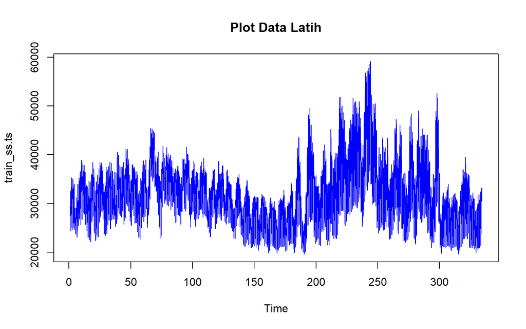

```r
# Eksplorasi data latih
plot(train_ss.ts, col="blue",main="Plot Data Latih")
```

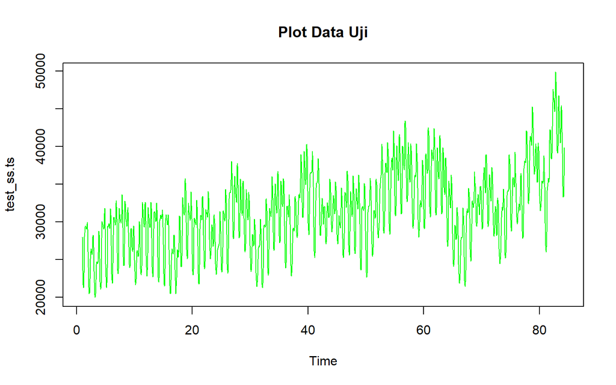

```r
# Eksplorasi data uji
plot(test_ss.ts, col="green",main="Plot Data Uji")
```

## 3. Winter Aditif

Perhitungan dengan model aditif dilakukan jika plot data asli menunjukkan fluktuasi musiman yang relatif stabil (konstan).

### a. Pemulusan

```r
# Pemulusan dengan winter aditif
winter1 <- HoltWinters(
  train_ss.ts,
  alpha = 0.2,
  beta = 0.1,
  gamma = 0.1,
  seasonal = "additive"
)

head(winter1$fitted, 100)
```

```
## Time Series:
## Start = c(2, 1)
## End = c(6, 4)
## Frequency = 24
##              xhat    level         trend     season
## 2.000000 30439.64 29895.86   42.58851449   501.1927
## 2.041667 30402.43 30128.12   61.55574783   212.7552
## 2.083333 30695.88 30332.59   75.84716954   287.4427
## 2.125000 32362.33 30509.46   85.94961351  1766.9219
## 2.166667 35071.02 30661.34   92.54299309  4317.1302
## 2.208333 35279.77 30790.48   96.20267023  4393.0885
## 2.250000 34918.40 30896.73   97.20719186  3924.4635
## 2.291667 34020.49 30980.86   95.89916533  2943.7344
## 2.333333 32410.94 31044.06   92.62934414  1274.2552
## 2.375000 30115.42 31088.10   87.77048363 -1060.4531
## 2.416667 27887.63 31114.19   81.60215222 -3308.1615
## 2.458333 26357.30 31123.86   74.40961071 -4840.9740
## 2.500000 26129.81 31120.01   66.58363529 -5056.7865
## 2.541667 25512.10 30988.43   46.76743225 -5523.0990
## 2.583333 25409.33 30880.98   31.34537117 -5502.9948
## 2.625000 26045.41 30751.06   15.21873156 -4720.8698
## 2.666667 28193.05 30744.20   13.01054523 -2564.1615
## 2.708333 31778.57 30683.00    5.58961860  1089.9844
## 2.750000 33387.29 30618.47   -1.42183175  2770.2344
## 2.791667 33257.52 30535.79   -9.54755539  2731.2760
## 2.833333 32757.45 30464.54  -15.71801653  2308.6302
## 2.875000 32271.79 30397.73  -20.82710844  1894.8802
## 2.916667 31612.21 30311.15  -27.40283980  1328.4635
## 2.958333 31042.04 30240.70  -31.70703476   833.0469
## 3.000000 30758.30 30212.59  -31.34791670   577.0616
## 3.041667 30476.95 30233.18  -26.15395925   269.9209
## 3.083333 30606.42 30295.84  -17.27289918   327.8525
## 3.125000 32173.29 30386.48   -6.48122492  1793.2954
## 3.166667 34809.06 30474.34    2.95288081  4331.7689
## 3.208333 34909.68 30506.68    5.89163730  4397.1066
## 3.250000 34430.95 30506.44    5.27805552  3919.2314
## 3.291667 33437.54 30502.53    4.35913285  2930.6551
## 3.333333 31798.50 30536.38    7.30833895  1254.8198
## 3.375000 29529.56 30601.58   13.09824354 -1085.1265
## 3.416667 27349.25 30667.77   18.40712667 -3336.9316
```

[output cut: 50 more lines]

```
## 5.541667 20660.53 26213.43   38.72592406 -5591.6241
## 5.583333 21376.41 26856.05   99.11526011 -5578.7528
## 5.625000 22832.80 27461.08  149.70699754 -4777.9861
## 5.666667 25426.92 27964.63  185.09091358 -2722.8025
## 5.708333 29213.92 28274.14  197.53255755   742.2523
## 5.750000 30772.21 28178.88  168.25412395  2425.0665
## 5.791667 30586.93 27923.30  125.87001160  2537.7638
## 5.833333 30066.46 27760.98   97.05137443  2208.4261
## 5.875000 29570.32 27646.74   75.92219143  1847.6526
## 5.916667 28907.82 27505.80   54.23587266  1347.7795
## 5.958333 28260.10 27378.07   36.03956174   845.9865
## 6.000000 27826.82 27259.69   20.59758221   546.5259
## 6.041667 27384.85 27145.93    7.16125880   231.7639
## 6.083333 27347.96 27083.32    0.18421509   264.4598
## 6.125000 28740.71 27100.71    1.90497606  1638.0912
```

```r
xhat1 <- winter1$fitted[, 2]

winter1.opt <- HoltWinters(
  train_ss.ts,
  alpha = NULL,
  beta = NULL,
  gamma = NULL,
  seasonal = "additive"
)

winter1.opt
```

```
## Holt-Winters exponential smoothing with trend and additive seasonal component.
##
## Call:
## HoltWinters(x = train_ss.ts, alpha = NULL, beta = NULL, gamma = NULL,     seasonal = "additive")
##
## Smoothing parameters:
##  alpha: 0.7987238
##  beta : 0.0007149766
##  gamma: 1
##
## Coefficients:
##             [,1]
## a   29129.581797
## b      -1.793768
## s1   -846.209764
## s2  -2994.758950
## s3  -4715.331676
## s4  -5843.322690
## s5  -6537.581788
## s6  -6843.378591
## s7  -6554.265552
## s8  -5072.013523
## s9  -2271.862686
## s10  -787.926398
## s11  -275.989698
## s12   408.483487
## s13  1093.649637
## s14  1434.493895
## s15  1591.542216
## s16  1847.120281
## s17  1857.164042
## s18  1968.303614
## s19  2256.878021
## s20  2647.655533
## s21  3616.717936
## s22  4034.478272
## s23  3003.967798
## s24  1339.418203
```

```r
head(winter1.opt$fitted, 100)
```

```
## Time Series:
## Start = c(2, 1)
## End = c(6, 4)
## Frequency = 24
##              xhat    level    trend     season
## 2.000000 30439.64 29895.86 42.58851   501.1927
## 2.041667 30951.81 30695.92 43.13009   212.7552
## 2.083333 31201.66 30871.00 43.22443   287.4427
## 2.125000 32723.84 30913.69 43.22405  1766.9219
## 2.166667 35291.82 30931.49 43.20587  4317.1302
## 2.208333 35380.76 30944.48 43.18427  4393.0885
## 2.250000 34914.75 30947.13 43.15529  3924.4635
## 2.291667 33927.82 30940.96 43.12002  2943.7344
## 2.333333 32244.85 30927.52 43.07958  1274.2552
## 2.375000 29891.80 30909.21 43.03569 -1060.4531
## 2.416667 27619.35 30884.52 42.98727 -3308.1615
## 2.458333 26056.51 30854.55 42.93510 -4840.9740
## 2.500000 25811.29 30825.19 42.88342 -5056.7865
## 2.541667 24850.50 30331.10 42.49949 -5523.0990
## 2.583333 24825.58 30286.14 42.43696 -5502.9948
## 2.625000 25472.24 30150.80 42.30985 -4720.8698
## 2.666667 28041.14 30562.73 42.57412 -2564.1615
## 2.708333 31562.70 30430.27 42.44898  1089.9844
## 2.750000 33177.73 30365.13 42.37205  2770.2344
## 2.791667 33023.90 30250.36 42.25970  2731.2760
## 2.833333 32583.65 30232.80 42.21693  2308.6302
## 2.875000 32146.85 30209.80 42.17031  1894.8802
## 2.916667 31459.67 30089.15 42.05389  1328.4635
## 2.958333 30956.22 30081.15 42.01810   833.0469
## 3.000000 30940.22 30206.06 42.07737   692.0753
## 3.041667 30598.39 30310.27 42.12179   246.0040
## 3.083333 30939.68 30610.06 42.30602   287.3092
## 3.125000 32620.10 30817.16 42.42385  1760.5139
## 3.166667 35231.43 30879.47 42.43807  4309.5175
## 3.208333 35127.07 30701.92 42.28078  4382.8727
## 3.250000 34500.23 30546.06 42.13911  3912.0355
## 3.291667 33467.71 30496.16 42.07330  2929.4802
## 3.333333 31932.84 30631.91 42.14028  1258.7862
## 3.375000 29762.69 30797.98 42.22889 -1077.5206
## 3.416667 27581.72 30866.02 42.24734 -3326.5473
```

[output cut: 50 more lines]

```
## 5.541667 23588.89 29173.82 39.58154 -5624.5172
## 5.583333 23744.65 29286.18 39.63357 -5581.1625
## 5.625000 24723.69 29454.69 39.72572 -4770.7186
## 5.666667 26597.88 29397.21 39.65622 -2838.9893
## 5.708333 29498.81 28998.47 39.34277   461.0033
## 5.750000 30105.14 27640.99 38.34408  2425.8094
## 5.791667 29361.55 26519.47 37.51481  2804.5593
## 5.833333 28818.83 26384.83 37.39171  2396.6110
## 5.875000 28539.21 26574.91 37.50089  1926.7941
## 5.916667 27994.39 26569.91 37.47050  1387.0014
## 5.958333 27409.60 26610.27 37.47257   761.8555
## 6.000000 27190.53 26710.36 37.51734   442.6435
## 6.041667 26900.74 26719.51 37.49705   143.7368
## 6.083333 27034.84 26865.04 37.57429   132.2307
## 6.125000 28657.33 27221.43 37.80224  1398.0949
```

```r
xhat1.opt <- winter1.opt$fitted[, 2]
```

### b. Peramalan

```r
# Peramalan 2000 periode ke depan
forecast1 <- predict(
  winter1,
  n.ahead = 2000
)

forecast1.opt <- predict(
  winter1.opt,
  n.ahead = 2000
)
```

### c. Plot Deret Waktu

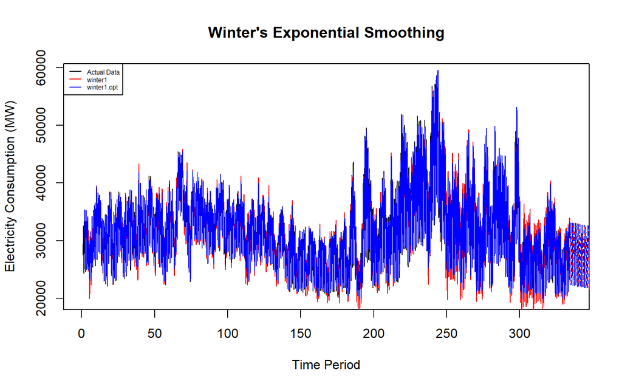

```r
# Plot Time Series
train_ss.ts <- ts(data3$PJME_MW[1:8000], frequency = 24)

# Pemodelan ulang dengan HoltWinters
winter1 <- HoltWinters(train_ss.ts, alpha = 0.2, beta = 0.1, gamma = 0.1)
winter1.opt <- HoltWinters(train_ss.ts)

# Ramal 2000 titik ke depan
forecast1 <- predict(winter1, n.ahead = 2000)
forecast1.opt <- predict(winter1.opt, n.ahead = 2000)

plot(
  train_ss.ts,
  main = "Winter's Exponential Smoothing",
  type = "l",
  col = "black",
  ylab = "Electricity Consumption (MW)",
  xlab = "Time Period"
)

# Garis hasil pemulusan masa lalu
lines(winter1$fitted[,1], col = "red")
lines(winter1.opt$fitted[,1], col = "blue")

# Garis hasil peramalan masa depan (putus-putus)
lines(forecast1, col = "red", lty = 2)
lines(forecast1.opt, col = "blue", lty = 2)

# Legenda (keterangan)
legend("topleft",c("Actual Data",expression(paste(winter1)),
                   expression(paste(winter1.opt))),cex=0.5,
       col=c("black","red","blue"),lty=1)
```

### d. Akurasi Data Latih

```r
#Akurasi data training
SSE1 <- winter1$SSE
MSE1 <- winter1$SSE/length(train_ss.ts)
RMSE1 <- sqrt(MSE1)
akurasi1 <- matrix(c(SSE1,MSE1,RMSE1))
row.names(akurasi1) <- c("SSE", "MSE", "RMSE")
colnames(akurasi1) <- c("Akurasi")
akurasi1
```

```
##           Akurasi
## SSE  1.891894e+10
## MSE  2.364868e+06
## RMSE 1.537813e+03
```

```r
SSE1.opt <- winter1.opt$SSE
MSE1.opt <- winter1.opt$SSE/length(train_ss.ts)
RMSE1.opt <- sqrt(MSE1.opt)
akurasi1.opt <- matrix(c(SSE1.opt,MSE1.opt,RMSE1.opt))
row.names(akurasi1.opt) <- c("SSE1.opt", "MSE1.opt", "RMSE1.opt")
colnames(akurasi1.opt) <- c("Akurasi")
akurasi1.opt
```

```
##                Akurasi
## SSE1.opt  3.844796e+09
## MSE1.opt  4.805996e+05
## RMSE1.opt 6.932529e+02
```

```r
akurasi1.train = data.frame(Model_Winter = c("Winter 1","Winter1 optimal"),
                            Nilai_SSE = c(SSE1,SSE1.opt),
                            Nilai_MSE = c(MSE1,MSE1.opt),Nilai_RMSE = c(RMSE1,RMSE1.opt))
akurasi1.train
```

```
##      Model_Winter   Nilai_SSE Nilai_MSE Nilai_RMSE
## 1        Winter 1 18918941019 2364867.6  1537.8126
## 2 Winter1 optimal  3844796451  480599.6   693.2529
```

Dari hasil tersebut, **Winter Additive optimal memiliki performa yang lebih baik** dibandingkan Winter 1. Hal ini terlihat dari nilai **SSE, MSE, dan RMSE yang lebih kecil**.

- Winter 1 menghasilkan RMSE sebesar **1.537,81 MW**.
- Winter Additive optimal menghasilkan RMSE sebesar **693,25 MW**.

Artinya, setelah parameter pemulusan dioptimalkan, model mampu menghasilkan nilai ramalan yang **lebih dekat dengan data aktual pada data latih**.

**Kesimpulan:**

Berdasarkan hasil akurasi data latih, model **Winter Additive optimal** memiliki performa yang lebih baik dibandingkan model Winter Additive dengan parameter awal. Model optimal menghasilkan nilai SSE sebesar **3,845 × 10⁹**, MSE sebesar **4,806 × 10⁵**, dan RMSE sebesar **693,25 MW**, sedangkan model Winter 1 menghasilkan SSE sebesar **1,892 × 10¹⁰**, MSE sebesar **2,365 × 10⁶**, dan RMSE sebesar **1.537,81 MW**. Dengan demikian, optimasi parameter pemulusan mampu meningkatkan akurasi model pada data latih.

### e. Akurasi Data Uji

```r
#Akurasi Data Testing
forecast1 <- data.frame(forecast1)
test_ss.ts <- data.frame(test_ss.ts)
selisih1 <- forecast1-test_ss.ts
SSEtesting1 <- sum(selisih1^2)
MSEtesting1 <- SSEtesting1/nrow(test_ss.ts)

forecast1.opt <- data.frame(forecast1.opt)
selisih1.opt <- forecast1.opt-test_ss.ts
SSEtesting1.opt <- sum(selisih1.opt^2)
MSEtesting1.opt <- SSEtesting1.opt/nrow(test_ss.ts)

akurasi_testing <- data.frame(
  Model = c("Model1", "Model Optimum"),
  SSE   = c(SSEtesting1, SSEtesting1.opt),
  MSE   = c(MSEtesting1, MSEtesting1.opt)
)

akurasi_testing
```

```
##           Model          SSE      MSE
## 1        Model1 160156308463 80078154
## 2 Model Optimum  98074467349 49037234
```

Berdasarkan hasil akurasi data uji, model **Winter Additive optimal** menghasilkan nilai SSE sebesar **9,807 × 10¹⁰** dan MSE sebesar **4,904 × 10⁷**, lebih kecil dibandingkan model Winter Additive 1 yang menghasilkan SSE sebesar **1,602 × 10¹¹** dan MSE sebesar **8,008 × 10⁷**. Dengan demikian, model Winter Additive optimal memberikan hasil peramalan yang lebih akurat pada data uji dibandingkan model dengan parameter awal.

## 4. Winter Multiplikatif

Model multiplikatif digunakan cocok digunakan jika plot data asli menunjukkan fluktuasi musiman yang bervariasi.

### a. Pemulusan

```r
#Pemulusan dengan winter multiplikatif
winter2 <- HoltWinters(
  train_ss.ts,
  alpha = 0.2,
  beta = 0.1,
  gamma = 0.3,
  seasonal = "multiplicative"
  )

head(winter2$fitted, 100)
```

```
## Time Series:
## Start = c(2, 1)
## End = c(6, 4)
## Frequency = 24
##              xhat    level       trend    season
## 2.000000 30449.30 29895.86   42.588514 1.0170635
## 2.041667 30416.78 30123.04   61.047511 1.0077093
## 2.083333 30705.72 30323.06   74.944773 1.0101229
## 2.125000 32354.39 30496.06   84.751146 1.0579964
## 2.166667 35053.26 30644.64   91.133134 1.1404713
## 2.208333 35277.20 30770.97   94.653427 1.1429283
## 2.250000 34928.62 30874.86   95.577431 1.1278049
## 2.291667 34035.93 30957.03   94.236498 1.0961206
## 2.333333 32419.37 31018.62   90.971622 1.0421020
## 2.375000 30102.33 31061.35   86.147338 0.9664445
## 2.416667 27846.07 31086.38   80.035716 0.8934639
## 2.458333 26292.54 31095.22   72.915807 0.8435711
## 2.500000 25886.06 31090.72   65.174024 0.8308561
## 2.541667 25317.40 30976.06   47.191126 0.8160783
## 2.583333 25276.86 30881.99   33.064957 0.8176229
## 2.625000 25979.03 30750.22   16.581655 0.8443851
## 2.666667 28195.18 30756.37   15.538764 0.9162634
## 2.708333 31827.55 30690.46    7.393110 1.0368006
## 2.750000 33429.19 30620.78   -0.314211 1.0917272
## 2.791667 33281.53 30538.36   -8.524883 1.0901314
## 2.833333 32771.33 30468.82  -14.625574 1.0760859
## 2.875000 32282.00 30404.14  -19.631379 1.0624494
## 2.916667 31626.40 30320.69  -26.012895 1.0439588
## 2.958333 31061.72 30250.73  -30.407655 1.0278421
## 3.000000 30930.47 30219.99  -30.441204 1.0245425
## 3.041667 30577.80 30206.63  -28.732621 1.0132513
## 3.083333 30647.44 30245.64  -21.958379 1.0140208
## 3.125000 32147.90 30322.02  -12.125144 1.0606405
## 3.166667 34718.92 30403.63   -2.751554 1.1420369
## 3.208333 34807.57 30442.40    1.400238 1.1433388
## 3.250000 34333.89 30456.29    2.649702 1.1272186
## 3.291667 33358.32 30468.01    3.556623 1.0947361
## 3.333333 31746.38 30512.98    7.697843 1.0401598
## 3.375000 29504.04 30586.36   14.266444 0.9641645
## 3.416667 27337.30 30660.98   20.301966 0.8910090
```

[output cut: 50 more lines]

```
## 5.541667 21319.87 26222.42   12.246228 0.8126602
## 5.583333 21844.51 26815.51   70.330335 0.8124912
## 5.625000 23067.93 27393.29  121.075349 0.8383960
## 5.666667 25227.49 27880.32  157.670670 0.8997612
## 5.708333 28420.19 28220.59  175.931250 1.0008333
## 5.750000 30009.73 28262.60  162.538705 1.0557462
## 5.791667 30274.56 28168.12  136.836905 1.0695850
## 5.833333 30052.82 28093.93  115.734204 1.0653377
## 5.875000 29727.49 28013.89   96.157012 1.0575396
## 5.916667 29205.39 27875.26   72.678206 1.0449927
## 5.958333 28522.96 27716.86   49.570111 1.0272462
## 6.000000 28026.17 27564.93   29.419998 1.0156492
## 6.041667 27540.92 27422.80   12.264984 1.0038585
## 6.083333 27420.35 27334.47    2.205446 1.0030611
## 6.125000 28527.80 27339.39    2.477607 1.0433742
```

```r
xhat2 <- winter2$fitted[,2]

winter2.opt <- HoltWinters(
  train_ss.ts,
  alpha = NULL,
  beta = NULL,
  gamma = NULL,
  seasonal = "multiplicative"
  )

winter2.opt
```

```
## Holt-Winters exponential smoothing with trend and multiplicative seasonal component.
##
## Call:
## HoltWinters(x = train_ss.ts, alpha = NULL, beta = NULL, gamma = NULL,     seasonal = "multiplicative")
##
## Smoothing parameters:
##  alpha: 0.8020065
##  beta : 0.0008378973
##  gamma: 1
##
## Coefficients:
##              [,1]
## a   28753.7542874
## b      -2.3578845
## s1      0.9797611
## s2      0.9005229
## s3      0.8367655
## s4      0.7946464
## s5      0.7679381
## s6      0.7550317
## s7      0.7633780
## s8      0.8135211
## s9      0.9076382
## s10     0.9568612
## s11     0.9757405
## s12     1.0009046
## s13     1.0257090
## s14     1.0381981
## s15     1.0441755
## s16     1.0537832
## s17     1.0556634
## s18     1.0620057
## s19     1.0757547
## s20     1.0939887
## s21     1.1336903
## s22     1.1531126
## s23     1.1185327
## s24     1.0596529
```

```r
head(winter2.opt$fitted, 100)
```

```
## Time Series:
## Start = c(2, 1)
## End = c(6, 4)
## Frequency = 24
##              xhat    level    trend    season
## 2.000000 30449.30 29895.86 42.58851 1.0170635
## 2.041667 30958.71 30678.66 43.20874 1.0077093
## 2.083333 31203.87 30847.85 43.31429 1.0101229
## 2.125000 32726.15 30888.88 43.31238 1.0579964
## 2.166667 35297.13 30906.31 43.29069 1.1404713
## 2.208333 35387.96 30919.27 43.26528 1.1429283
## 2.250000 34922.59 30921.87 43.23121 1.1278049
## 2.291667 33934.58 30915.61 43.18974 1.0961206
## 2.333333 32248.04 30902.04 43.14218 1.0421020
## 2.375000 29888.92 30883.58 43.09057 0.9664445
## 2.416667 27609.58 30858.70 43.03361 0.8934639
## 2.458333 26042.28 30828.50 42.97225 0.8435711
## 2.500000 25625.15 30798.95 42.91148 0.8308561
## 2.541667 24821.11 30372.59 42.51829 0.8160783
## 2.583333 24838.43 30336.38 42.45232 0.8176229
## 2.625000 25492.12 30147.90 42.25882 0.8443851
## 2.666667 28086.61 30610.81 42.61128 0.9162634
## 2.708333 31585.33 30421.81 42.41722 1.0368006
## 2.750000 33171.96 30342.53 42.31524 1.0917272
## 2.791667 33016.55 30244.56 42.19770 1.0901314
## 2.833333 32583.04 30237.06 42.15606 1.0760859
## 2.875000 32150.70 30218.82 42.10545 1.0624494
## 2.916667 31471.30 30104.14 41.97408 1.0439588
## 2.958333 30969.87 30089.03 41.92626 1.0278421
## 3.000000 30942.55 30201.29 41.98518 1.0231217
## 3.041667 30609.21 30302.42 42.03474 1.0087252
## 3.083333 30944.13 30592.34 42.24245 1.0101046
## 3.125000 32618.94 30794.86 42.37674 1.0577777
## 3.166667 35231.33 30857.00 42.39330 1.1401951
## 3.208333 35131.30 30705.72 42.23102 1.1425572
## 3.250000 34511.78 30570.86 42.08264 1.1273592
## 3.291667 33487.46 30522.75 42.00707 1.0956235
## 3.333333 31954.09 30636.15 42.06689 1.0415889
## 3.375000 29772.98 30781.32 42.15328 0.9659189
## 3.416667 27577.50 30841.76 42.16860 0.8929400
```

[output cut: 50 more lines]

```
## 5.541667 23546.46 28893.51 38.84549 0.8138452
## 5.583333 23721.92 29063.95 38.95576 0.8151049
## 5.625000 24698.50 29284.03 39.10752 0.8422871
## 5.666667 26532.01 29231.25 39.03053 0.9064489
## 5.708333 29314.40 28842.92 38.67244 1.0149856
## 5.750000 29917.65 27645.46 37.63669 1.0807192
## 5.791667 29284.55 26744.59 36.85032 1.0934643
## 5.833333 28833.11 26679.82 36.76517 1.0792212
## 5.875000 28590.08 26848.04 36.87532 1.0634246
## 5.916667 28064.83 26806.42 36.80955 1.0455087
## 5.958333 27492.70 26791.96 36.76659 1.0247484
## 6.000000 27233.90 26825.05 36.76351 1.0138516
## 6.041667 26943.70 26799.41 36.71122 1.0040090
## 6.083333 27050.99 26909.84 36.77299 1.0038734
## 6.125000 28545.47 27252.61 37.02938 1.0460188
```

```r
xhat2.opt <- winter2.opt$fitted[,2]
```

### b. Peramalan

```r
forecast2 <- predict(
  winter2,
  n.ahead = 2000
)

forecast2.opt <- predict(
  winter2.opt,
  n.ahead = 2000
)
```

### c. Plot Deret Waktu

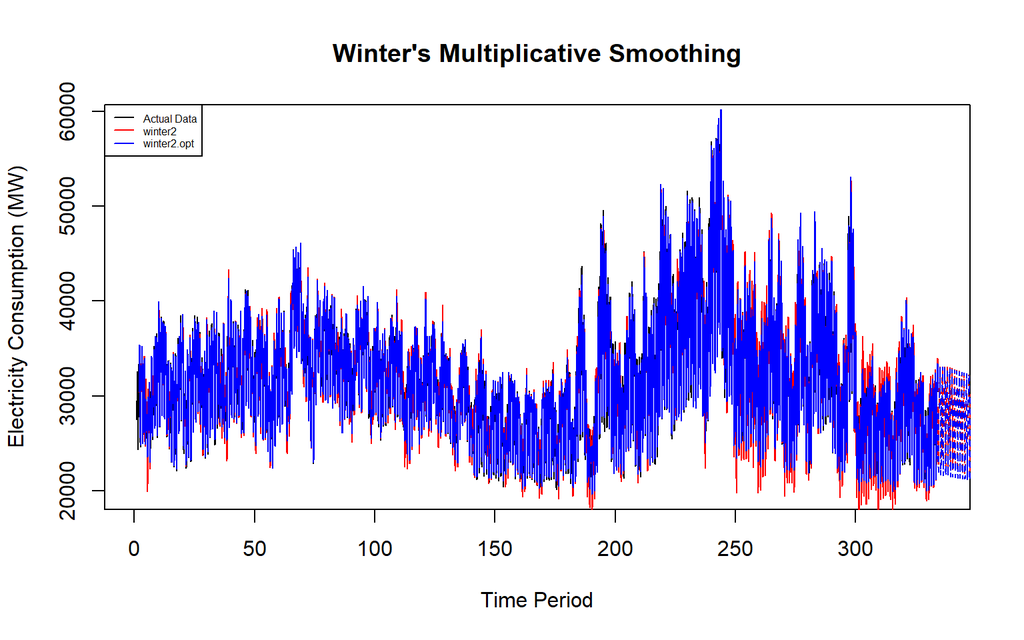

```r
# Plot Time Series
train_ss.ts <- ts(data3$PJME_MW[1:8000], frequency = 24)

# Pemodelan ulang dengan HoltWinters
winter2 <- HoltWinters(train_ss.ts, alpha = 0.2, beta = 0.1, gamma = 0.1)
winter2.opt <- HoltWinters(train_ss.ts, seasonal = "multiplicative")

# Ramal 2000 titik ke depan
forecast2 <- predict(winter2, n.ahead = 2000)
forecast2.opt <- predict(winter2.opt, n.ahead = 2000)

plot(
  train_ss.ts,
  main = "Winter's Multiplicative Smoothing",
  type = "l",
  col = "black",
  ylab = "Electricity Consumption (MW)",
  xlab = "Time Period"
)

# Garis hasil pemulusan masa lalu
lines(winter2$fitted[,1], col = "red")
lines(winter2.opt$fitted[,1], col = "blue")

# Garis hasil peramalan masa depan (putus-putus)
lines(forecast2, col = "red", lty = 2)
lines(forecast2.opt, col = "blue", lty = 2)

# Legenda (keterangan)
legend("topleft",c("Actual Data", expression(paste(winter2)),
                   expression(paste(winter2.opt))),cex=0.5,
       col=c("black","red","blue"),lty=1)
```

### d. Akurasi Data Latih

```r
#Akurasi data training
SSE2 <- winter2$SSE
MSE2 <- winter2$SSE/length(train_ss.ts)
RMSE2 <- sqrt(MSE2)
akurasi1 <- matrix(c(SSE2,MSE2,RMSE2))
row.names(akurasi1) <- c("SSE2", "MSE2", "RMSE2")
colnames(akurasi1) <- c("Akurasi lamda=0.2")
akurasi1
```

```
##       Akurasi lamda=0.2
## SSE2       1.891894e+10
## MSE2       2.364868e+06
## RMSE2      1.537813e+03
```

```r
SSE2.opt <- winter2.opt$SSE
MSE2.opt <- winter2.opt$SSE/length(train_ss.ts)
RMSE2.opt <- sqrt(MSE2.opt)
akurasi1.opt <- matrix(c(SSE2.opt,MSE2.opt,RMSE2.opt))
row.names(akurasi1.opt) <- c("SSE2.opt", "MSE2.opt", "RMSE2.opt")
colnames(akurasi1.opt) <- c("Akurasi")
akurasi1.opt
```

```
##                Akurasi
## SSE2.opt  3.087429e+09
## MSE2.opt  3.859286e+05
## RMSE2.opt 6.212315e+02
```

```r
akurasi2.train = data.frame(Model_Winter = c("Winter 1","winter2 optimal"),
                            Nilai_SSE=c(SSE2,SSE2.opt),
                            Nilai_MSE=c(MSE2,MSE2.opt),Nilai_RMSE=c(RMSE2,RMSE2.opt))
akurasi2.train
```

```
##      Model_Winter   Nilai_SSE Nilai_MSE Nilai_RMSE
## 1        Winter 1 18918941019 2364867.6  1537.8126
## 2 winter2 optimal  3087428576  385928.6   621.2315
```

- SSE: **18,92 miliar → 3,09 miliar**
- MSE: **2,36 juta → 385.929**
- RMSE: **1.537,81 MW → 621,23 MW**

Jadi, untuk **data latih Winter Multiplicative**, model optimal memberikan hasil pemulusan yang lebih dekat dengan data aktual.

**Kesimpulan:**

### e. Akurasi Data Uji

```r
#Akurasi Data Testing
forecast2 <- data.frame(forecast2)
test_ss.ts <- data.frame(test_ss.ts)
selisih2 <- forecast2-test_ss.ts
SSEtesting2 <- sum(selisih2^2)
MSEtesting2 <- SSEtesting2/nrow(test_ss.ts)

forecast2.opt <- data.frame(forecast2.opt)
selisih2.opt <- forecast2.opt-test_ss.ts
SSEtesting2.opt <- sum(selisih2.opt^2)
MSEtesting2.opt <- SSEtesting2.opt/nrow(test_ss.ts)

# Tabel
akurasi_testing2 <- data.frame(
  Model = c("Model2", "Model2 Optimal"),
  SSE   = c(SSEtesting2, SSEtesting2.opt),
  MSE   = c(MSEtesting2, MSEtesting2.opt)
)

akurasi_testing2
```

```
##            Model          SSE      MSE
## 1         Model2 160156308463 80078154
## 2 Model2 Optimal 122962741868 61481371
```

# Perbandingan Metode

```r
perbandingan <- data.frame(
  Metode = c(
    "SMA",
    "DMA",
    "SES",
    "DES",
    "Winter Additive",
    "Winter Multiplicative"
  ),

  MSE_Test = c(
    MSE_test.sma,
    MSE_test.dma,
    MSEtesting1,       # SES terbaik
    MSEtestingdes2,    # DES terbaik
    MSEtesting1.opt,   # Winter additive optimal
    MSEtesting2.opt    # Winter multiplicative optimal
  )
)

perbandingan <- perbandingan[order(perbandingan$MSE_Test), ]

perbandingan
```

```
##                  Metode     MSE_Test
## 1                   SMA     34337647
## 5       Winter Additive     49037234
## 6 Winter Multiplicative     61481371
## 3                   SES     80078154
## 2                   DMA   1629621326
## 4                   DES 110228942499
```